# Hongple

Joel Lee

#### 가설

```
초당 센서 값들의 각 조합에 대한 발생빈도를 계산, 발생 확률이 극히 낮거나 처음 발견되는 센서 값의 조합 발생시 이상패턴으로 정의, 탐지 가능하다.
```

#### 대상 데이터

- 단말사양 : AVN4 RC
- 국가 : 국내
- 차종 : UM
- 종류 : 주기적 운행 로그 (월 1회, vin별 1 trip, 1시간 이내 sample rate : 1 sec.)
- 테이블 : hkmc_tms.drv_rg_log_ps_avn4_rc
- 센서 : 227개
- 기간 : 6개월
- 클러스터 : 분석계 대화형
- 데이터베이스 : vcrm_6442267

#### 분석 프로세스

```
연속형센서 범주화 및 기초 통계 -> 이상 패턴 탐색 -> 고장 조기 감지
```

##### 초기화 및 대화형 임팔라 접속

```
## character(0)
```

##### 1차 데이터 가공

- drv_rg_log_ps_avn4_rc_seq : 정기 운행로그에 주행별 시퀀스 추가(61,972,965건)

| 차종 | 레코드수(초당) |
| --- | --- |
| DM | 19110538 |
| UM | 36321553 |
| KH | 106191 |
| AG | 6432762 |
| TL | 1921 |

| 차종 | 주행 횟수 | 최초 주행시간 | 최종 주행시간 | 평균 주행(초수) |
| --- | --- | --- | --- | --- |
| DM | 12410 | 20141102020436 | 20150405185031 | 1534 |
| UM | 24863 | 20141001055302 | 20150405175643 | 1446 |
| KH | 78 | 20150111002956 | 20150405095542 | 1361 |
| AG | 4655 | 20141111093204 | 20150405104945 | 1379 |
| TL | 1 | 20150404181150 | 20150404181150 | 1921 |

| 차종 | 차량대수 |
| --- | --- |
| UM | 4904 |
| AG | 703 |
| DM | 5578 |
| TL | 1 |
| KH | 49 |

샘플 데이터 가져오기

```
## geom_smooth: method="auto" and size of largest group is >=1000, so using gam with formula: y ~ s(x, bs = "cs"). Use 'method = x' to change the smoothing method.
```

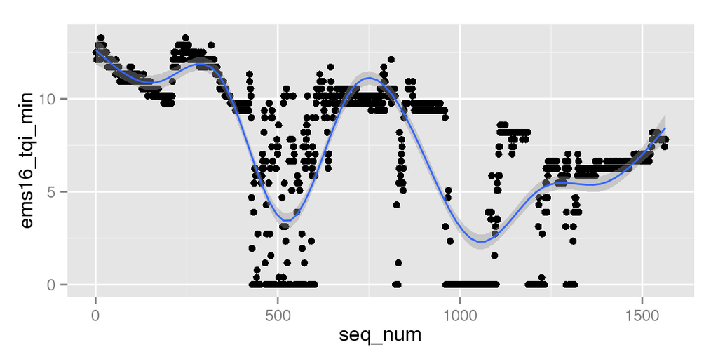

```r
df_sample = data.frame(sqlQuery( conn, "select * from vcrm_6442267.drv_rg_log_ps_avn4_rc_seq
                                 where vin = 'KNAPK81ABFA010727' and ignitiontime = '20141211074429'
                                 order by seq_num"))

#plot(df$seq_num, df$ems16_tqi_min, type="l", ylab="ems16_tqi_min", xlab="time(sec)")
qplot(seq_num, ems16_tqi_min, data = df_sample) + geom_smooth()
```

연속형 멀티센서 시계열 탐색

[figure not shown]

```r
# timeseries multiple plot
# par(pch=22, col="red") # plotting symbol and color
graphics.off()    # close graphics windows
# 20 of 227 plots on one page
par(mfrow=c(5, 4), mar = c(2, 2, 2, 1), oma = c(0, 0, 1, 0))
signals = names(df_sample)

for(i in 7:25){
    signal_ts <- df_sample[,i]
    plot.ts(signal_ts, type="l", main=signals[i])
    }
```

##### 2차 데이터 가공

- drv_rg_log_ps_avn4_rc_factor10 : 연속형 센서 범주화 (10개씩 쪼개기)
- 전체 센서들에 대한 조합의 빈도수가 높지 않아 불필요한 센서 제거해야함.
- engfrzfrm12 센서그룹 제외(NULL 만 들어있음)
- 주요 센서그룹 Null 비율

| 센서그룹 | 전체 NULL(건수) | 전체 NULL(비율) | UM NULL(건수) | UM NULL(비율) |
| --- | --- | --- | --- | --- |
| engfrzfrm12 | 61,972,965 | 100% | 36,321,553 | 100% |
| ems19 | 25,649,491 | 41.388194% | 0 | 0% |
| fatc11 | 25,650,803 | 41.3903111% | 1,312 | 0.0036122% |
| bat11 | 25,650,996 | 41.3906225% | 1,505 | 0.0041435% |
| cgw1 | 26,613,289 | 42.9433851% | 963,797 | 2.6535126% |

##### 3차 데이터 가공

UM(Disel) 차종의 센서그룹별 센서조합의 통계를 구해서 센서별 특징을 파악한다.

|  | vars | n | mean | sd | median | trimmed | mad | min | max | range | skew | kurtosis | se |
| --- | --- | --- | --- | --- | --- | --- | --- | --- | --- | --- | --- | --- | --- |
| ems11_swi_igk | 1 | 1049.00 | 0.99 | 0.10 | 1.00 | 1.00 | 0.00 | 0.00 | 1.00 | 1.00 | -10.08 | 99.71 | 0.00 |
| ems11_f_n_eng | 2 | 1049.00 | 0.00 | 0.00 | 0.00 | 0.00 | 0.00 | 0.00 | 0.00 | 0.00 |  |  | 0.00 |
| ems11_ack_tcs | 3 | 1049.00 | 1.00 | 0.07 | 1.00 | 1.00 | 0.00 | 0.00 | 1.00 | 1.00 | -14.36 | 204.41 | 0.00 |
| ems11_puc_stat | 4 | 1049.00 | 0.05 | 0.22 | 0.00 | 0.00 | 0.00 | 0.00 | 1.00 | 1.00 | 4.10 | 14.81 | 0.01 |
| ems11_tq_cor_stat | 5 | 1049.00 | 0.00 | 0.00 | 0.00 | 0.00 | 0.00 | 0.00 | 0.00 | 0.00 |  |  | 0.00 |
| ems11_rly_ac | 6 | 1049.00 | 0.39 | 0.49 | 0.00 | 0.37 | 0.00 | 0.00 | 1.00 | 1.00 | 0.43 | -1.82 | 0.02 |
| ems11_f_sub_tqi | 7 | 1049.00 | 0.00 | 0.00 | 0.00 | 0.00 | 0.00 | 0.00 | 0.00 | 0.00 |  |  | 0.00 |
| ems11_tqi_acor | 8 | 1049.00 | 3.93 | 2.58 | 4.00 | 3.88 | 2.97 | 0.00 | 9.00 | 9.00 | 0.12 | -1.03 | 0.08 |
| ems11_n | 9 | 1049.00 | 1.06 | 0.72 | 1.00 | 1.08 | 1.48 | 0.00 | 3.00 | 3.00 | -0.08 | -1.02 | 0.02 |
| ems11_tqi | 10 | 1049.00 | 4.49 | 2.76 | 5.00 | 4.54 | 2.97 | 0.00 | 9.00 | 9.00 | -0.12 | -1.13 | 0.09 |
| ems11_tqfr | 11 | 1049.00 | 0.30 | 0.46 | 0.00 | 0.25 | 0.00 | 0.00 | 1.00 | 1.00 | 0.86 | -1.27 | 0.01 |
| ems11_vs | 12 | 1049.00 | 2.49 | 1.93 | 2.00 | 2.33 | 1.48 | 0.00 | 8.00 | 8.00 | 0.57 | -0.50 | 0.06 |
| ems11_ratio_tqi_bas_max_stnd | 13 | 1049.00 | 0.00 | 0.00 | 0.00 | 0.00 | 0.00 | 0.00 | 0.00 | 0.00 |  |  | 0.00 |
| cnt | 14 | 1049.00 | 33948.54 | 375693.06 | 10.00 | 459.60 | 13.34 | 1.00 | 10900873.00 | 10900872.00 | 24.70 | 681.93 | 11599.66 |
| id | 15 | 1049.00 | 525.00 | 302.96 | 525.00 | 525.00 | 388.44 | 1.00 | 1049.00 | 1048.00 | 0.00 | -1.20 | 9.35 |
| pct | 16 | 1049.00 | 0.00 | 0.01 | 0.00 | 0.00 | 0.00 | 0.00 | 0.31 | 0.31 | 24.70 | 681.93 | 0.00 |

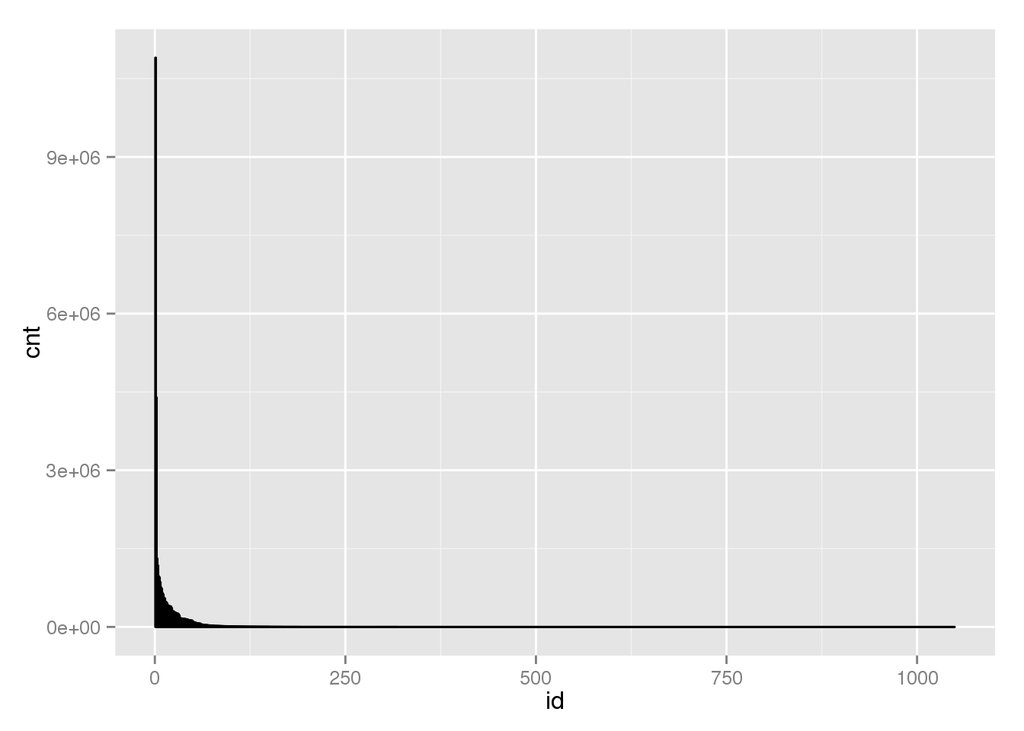

|  | vars | n | mean | sd | median | trimmed | mad | min | max | range | skew | kurtosis | se |
| --- | --- | --- | --- | --- | --- | --- | --- | --- | --- | --- | --- | --- | --- |
| ems16_tqi_min | 1 | 1359.00 | 0.46 | 0.97 | 0.00 | 0.21 | 0.00 | 0.00 | 6.00 | 6.00 | 2.71 | 8.03 | 0.03 |
| ems16_tqi | 2 | 1359.00 | 3.17 | 2.01 | 3.00 | 3.07 | 1.48 | 0.00 | 9.00 | 9.00 | 0.44 | -0.25 | 0.05 |
| ems16_tqi_target | 3 | 1359.00 | 2.73 | 2.75 | 2.00 | 2.40 | 2.97 | 0.00 | 9.00 | 9.00 | 0.71 | -0.66 | 0.07 |
| ems16_glow_stat | 4 | 1359.00 | 0.03 | 0.18 | 0.00 | 0.00 | 0.00 | 0.00 | 1.00 | 1.00 | 5.09 | 23.91 | 0.00 |
| ems16_cruise_lamp_m | 5 | 1359.00 | 0.39 | 0.49 | 0.00 | 0.37 | 0.00 | 0.00 | 1.00 | 1.00 | 0.44 | -1.81 | 0.01 |
| ems16_cruise_lamp_s | 6 | 1359.00 | 0.17 | 0.37 | 0.00 | 0.09 | 0.00 | 0.00 | 1.00 | 1.00 | 1.77 | 1.13 | 0.01 |
| ems16_pre_fuel_cut_in | 7 | 1359.00 | 0.00 | 0.00 | 0.00 | 0.00 | 0.00 | 0.00 | 0.00 | 0.00 |  |  | 0.00 |
| ems16_eng_stat | 8 | 1359.00 | 2.65 | 0.83 | 3.00 | 2.86 | 0.00 | 0.00 | 3.00 | 3.00 | -2.11 | 2.94 | 0.02 |
| ems16_soak_time_error | 9 | 1359.00 | 0.00 | 0.00 | 0.00 | 0.00 | 0.00 | 0.00 | 0.00 | 0.00 |  |  | 0.00 |
| ems16_soak_time | 10 | 1359.00 | 0.49 | 1.93 | 0.00 | 0.00 | 0.00 | 0.00 | 10.00 | 10.00 | 4.15 | 16.26 | 0.05 |
| ems16_tqi_max | 11 | 1359.00 | 5.24 | 2.42 | 5.00 | 5.28 | 2.97 | 0.00 | 9.00 | 9.00 | -0.13 | -0.83 | 0.07 |
| ems16_spk_time_cur | 12 | 1359.00 | -3.00 | 0.00 | -3.00 | -3.00 | 0.00 | -3.00 | -3.00 | 0.00 |  |  | 0.00 |
| ems16_cf_ems_aclact | 13 | 1359.00 | 0.00 | 0.00 | 0.00 | 0.00 | 0.00 | 0.00 | 0.00 | 0.00 |  |  | 0.00 |
| cnt | 14 | 1359.00 | 26204.58 | 225485.24 | 24.00 | 380.63 | 34.10 | 1.00 | 3727912.00 | 3727911.00 | 12.62 | 176.06 | 6116.58 |
| id | 15 | 1359.00 | 680.00 | 392.45 | 680.00 | 680.00 | 504.08 | 1.00 | 1359.00 | 1358.00 | 0.00 | -1.20 | 10.65 |
| pct | 16 | 1359.00 | 0.00 | 0.01 | 0.00 | 0.00 | 0.00 | 0.00 | 0.10 | 0.10 | 12.62 | 176.06 | 0.00 |

|  | vars | n | mean | sd | median | trimmed | mad | min | max | range | skew | kurtosis | se |
| --- | --- | --- | --- | --- | --- | --- | --- | --- | --- | --- | --- | --- | --- |
| ems_h12_r_tqacnapvc | 1 | 1612.00 | 2.68 | 4.43 | 0.00 | 2.10 | 0.00 | 0.00 | 10.00 | 10.00 | 1.05 | -0.91 | 0.11 |
| ems_h12_r_pacnc | 2 | 1612.00 | 0.73 | 0.92 | 0.00 | 0.57 | 0.00 | 0.00 | 5.00 | 5.00 | 1.35 | 1.54 | 0.02 |
| ems_h12_tqi_b | 3 | 1612.00 | 2.89 | 2.42 | 2.00 | 2.64 | 2.97 | 0.00 | 9.00 | 9.00 | 0.72 | -0.35 | 0.06 |
| ems_h12_sld_vs | 4 | 1612.00 | 0.34 | 1.05 | 0.00 | 0.00 | 0.00 | 0.00 | 5.00 | 5.00 | 3.00 | 7.67 | 0.03 |
| ems_h12_cf_cdastat | 5 | 1612.00 | 0.00 | 0.00 | 0.00 | 0.00 | 0.00 | 0.00 | 0.00 | 0.00 |  |  | 0.00 |
| ems_h12_cf_ems_isgstat | 6 | 1612.00 | 1.19 | 1.58 | 0.00 | 0.97 | 0.00 | 0.00 | 7.00 | 7.00 | 0.92 | -0.46 | 0.04 |
| ems_h12_cf_ems_oilchg | 7 | 1612.00 | 0.00 | 0.00 | 0.00 | 0.00 | 0.00 | 0.00 | 0.00 | 0.00 |  |  | 0.00 |
| ems_h12_cf_ems_etclimpmod | 8 | 1612.00 | 0.00 | 0.00 | 0.00 | 0.00 | 0.00 | 0.00 | 0.00 | 0.00 |  |  | 0.00 |
| ems_h12_r_nengidltgc | 9 | 1612.00 | 3.10 | 0.34 | 3.00 | 3.00 | 0.00 | 0.00 | 5.00 | 5.00 | 2.59 | 13.53 | 0.01 |
| ems_h12_cf_ems_uptargr | 10 | 1612.00 | 0.12 | 0.33 | 0.00 | 0.03 | 0.00 | 0.00 | 1.00 | 1.00 | 2.32 | 3.40 | 0.01 |
| ems_h12_cf_ems_downtargr | 11 | 1612.00 | 0.08 | 0.28 | 0.00 | 0.00 | 0.00 | 0.00 | 1.00 | 1.00 | 2.99 | 6.93 | 0.01 |
| ems_h12_cf_ems_descurgr | 12 | 1612.00 | 1.46 | 2.05 | 0.00 | 1.12 | 0.00 | 0.00 | 6.00 | 6.00 | 1.03 | -0.48 | 0.05 |
| ems_h12_cf_ems_sldact | 13 | 1612.00 | 0.00 | 0.00 | 0.00 | 0.00 | 0.00 | 0.00 | 0.00 | 0.00 |  |  | 0.00 |
| ems_h12_cf_ems_sldposact | 14 | 1612.00 | 0.00 | 0.00 | 0.00 | 0.00 | 0.00 | 0.00 | 0.00 | 0.00 |  |  | 0.00 |
| ems_h12_cf_ems_hpresstat | 15 | 1612.00 | 0.00 | 0.00 | 0.00 | 0.00 | 0.00 | 0.00 | 0.00 | 0.00 |  |  | 0.00 |
| ems_h12_cf_ems_isgbuz | 16 | 1612.00 | 0.04 | 0.20 | 0.00 | 0.00 | 0.00 | 0.00 | 1.00 | 1.00 | 4.71 | 20.20 | 0.00 |
| ems_h12_cf_ems_idlstpfco | 17 | 1612.00 | 0.00 | 0.00 | 0.00 | 0.00 | 0.00 | 0.00 | 0.00 | 0.00 |  |  | 0.00 |
| ems_h12_cf_ems_fcopen | 18 | 1612.00 | 0.00 | 0.00 | 0.00 | 0.00 | 0.00 | 0.00 | 0.00 | 0.00 |  |  | 0.00 |
| ems_h12_cf_ems_actecoact | 19 | 1612.00 | 0.30 | 0.46 | 0.00 | 0.25 | 0.00 | 0.00 | 1.00 | 1.00 | 0.86 | -1.26 | 0.01 |
| ems_h12_cf_ems_engrunnorm | 20 | 1612.00 | 0.82 | 0.38 | 1.00 | 0.90 | 0.00 | 0.00 | 1.00 | 1.00 | -1.66 | 0.76 | 0.01 |
| ems_h12_cf_ems_isgstat2 | 21 | 1612.00 | 0.10 | 0.54 | 0.00 | 0.00 | 0.00 | 0.00 | 3.00 | 3.00 | 5.18 | 24.85 | 0.01 |
| cnt | 22 | 1612.00 | 22091.82 | 183356.00 | 22.00 | 236.04 | 31.13 | 1.00 | 4007872.00 | 4007871.00 | 13.79 | 228.17 | 4566.81 |
| id | 23 | 1612.00 | 806.50 | 465.49 | 806.50 | 806.50 | 597.49 | 1.00 | 1612.00 | 1611.00 | 0.00 | -1.20 | 11.59 |
| pct | 24 | 1612.00 | 0.00 | 0.01 | 0.00 | 0.00 | 0.00 | 0.00 | 0.11 | 0.11 | 13.79 | 228.17 | 0.00 |

|  | vars | n | mean | sd | median | trimmed | mad | min | max | range | skew | kurtosis | se |
| --- | --- | --- | --- | --- | --- | --- | --- | --- | --- | --- | --- | --- | --- |
| tcu11_tqi_tcu_inc | 1 | 674.00 | 0.02 | 0.14 | 0.00 | 0.00 | 0.00 | 0.00 | 2.00 | 2.00 | 9.24 | 94.76 | 0.01 |
| tcu11_g_sel_disp | 2 | 674.00 | 6.00 | 2.40 | 5.00 | 5.80 | 0.00 | 0.00 | 15.00 | 15.00 | 1.18 | 4.51 | 0.09 |
| tcu11_f_tcu | 3 | 674.00 | 0.13 | 0.34 | 0.00 | 0.04 | 0.00 | 0.00 | 2.00 | 2.00 | 2.28 | 3.61 | 0.01 |
| tcu11_tcu_type | 4 | 674.00 | 1.00 | 0.04 | 1.00 | 1.00 | 0.00 | 0.00 | 1.00 | 1.00 | -25.85 | 667.01 | 0.00 |
| tcu11_tcu_obd | 5 | 674.00 | 0.26 | 0.67 | 0.00 | 0.07 | 0.00 | 0.00 | 2.00 | 2.00 | 2.21 | 2.88 | 0.03 |
| tcu11_swi_gs | 6 | 674.00 | 0.75 | 0.43 | 1.00 | 0.81 | 0.00 | 0.00 | 1.00 | 1.00 | -1.17 | -0.64 | 0.02 |
| tcu11_gear_type | 7 | 674.00 | 5.99 | 0.23 | 6.00 | 6.00 | 0.00 | 0.00 | 6.00 | 6.00 | -25.85 | 667.01 | 0.01 |
| tcu11_tqi_tcu | 8 | 674.00 | 5.99 | 3.09 | 7.00 | 6.26 | 2.97 | 0.00 | 9.00 | 9.00 | -0.40 | -1.42 | 0.12 |
| tcu11_temp_at | 9 | 674.00 | 1.39 | 1.06 | 1.00 | 1.35 | 1.48 | -1.00 | 4.00 | 5.00 | 0.25 | -0.80 | 0.04 |
| tcu11_n_tc | 10 | 674.00 | 0.66 | 0.72 | 1.00 | 0.57 | 1.48 | 0.00 | 3.00 | 3.00 | 0.67 | -0.67 | 0.03 |
| tcu11_swi_cc | 11 | 674.00 | 0.84 | 0.84 | 1.00 | 0.80 | 1.48 | 0.00 | 2.00 | 2.00 | 0.30 | -1.50 | 0.03 |
| cnt | 12 | 674.00 | 52836.82 | 345260.72 | 24.00 | 583.01 | 34.10 | 1.00 | 4645304.00 | 4645303.00 | 8.67 | 84.39 | 13298.95 |
| id | 13 | 674.00 | 337.50 | 194.71 | 337.50 | 337.50 | 249.82 | 1.00 | 674.00 | 673.00 | 0.00 | -1.21 | 7.50 |
| pct | 14 | 674.00 | 0.00 | 0.01 | 0.00 | 0.00 | 0.00 | 0.00 | 0.13 | 0.13 | 8.67 | 84.39 | 0.00 |

|  | vars | n | mean | sd | median | trimmed | mad | min | max | range | skew | kurtosis | se |
| --- | --- | --- | --- | --- | --- | --- | --- | --- | --- | --- | --- | --- | --- |
| tcu12_etl_tcu | 1 | 9979.00 | 6.58 | 3.21 | 6.00 | 6.77 | 5.93 | 0.00 | 10.00 | 10.00 | -0.18 | -1.56 | 0.03 |
| tcu12_cur_gr | 2 | 9979.00 | 3.58 | 1.93 | 4.00 | 3.56 | 1.48 | 0.00 | 14.00 | 14.00 | 1.20 | 6.30 | 0.02 |
| tcu12_cf_tcu_alive | 3 | 9979.00 | 1.50 | 1.12 | 1.00 | 1.50 | 1.48 | 0.00 | 3.00 | 3.00 | 0.00 | -1.36 | 0.01 |
| tcu12_cf_tcu_chksum | 4 | 9979.00 | 1.50 | 1.12 | 2.00 | 1.51 | 1.48 | 0.00 | 3.00 | 3.00 | -0.01 | -1.36 | 0.01 |
| tcu12_vs_tcu | 5 | 9979.00 | 1.76 | 1.52 | 2.00 | 1.57 | 1.48 | 0.00 | 8.00 | 8.00 | 1.00 | 0.96 | 0.02 |
| tcu12_fuel_cut_tcu | 6 | 9979.00 | 0.00 | 0.00 | 0.00 | 0.00 | 0.00 | 0.00 | 0.00 | 0.00 |  |  | 0.00 |
| tcu12_inh_fuel_cut | 7 | 9979.00 | 0.52 | 0.50 | 1.00 | 0.53 | 0.00 | 0.00 | 1.00 | 1.00 | -0.08 | -1.99 | 0.01 |
| tcu12_idle_up_tcu | 8 | 9979.00 | 0.00 | 0.00 | 0.00 | 0.00 | 0.00 | 0.00 | 0.00 | 0.00 |  |  | 0.00 |
| tcu12_n_inc_tcu | 9 | 9979.00 | 0.00 | 0.00 | 0.00 | 0.00 | 0.00 | 0.00 | 0.00 | 0.00 |  |  | 0.00 |
| tcu12_spk_rtd_tcu | 10 | 9979.00 | 5.00 | 0.10 | 5.00 | 5.00 | 0.00 | -5.00 | 5.00 | 10.00 | -99.86 | 9972.00 | 0.00 |
| tcu12_n_tc_raw | 11 | 9979.00 | 0.58 | 0.62 | 1.00 | 0.51 | 1.48 | 0.00 | 3.00 | 3.00 | 0.60 | -0.56 | 0.01 |
| tcu12_vs_tcu_decimal | 12 | 9979.00 | 4.48 | 2.89 | 4.00 | 4.48 | 4.45 | 0.00 | 9.00 | 9.00 | -0.00 | -1.24 | 0.03 |
| cnt | 13 | 9979.00 | 3568.70 | 50074.40 | 9.00 | 55.60 | 11.86 | 1.00 | 2338610.00 | 2338609.00 | 41.70 | 1886.01 | 501.27 |
| id | 14 | 9979.00 | 4990.00 | 2880.83 | 4990.00 | 4990.00 | 3699.09 | 1.00 | 9979.00 | 9978.00 | 0.00 | -1.20 | 28.84 |
| pct | 15 | 9979.00 | 0.00 | 0.00 | 0.00 | 0.00 | 0.00 | 0.00 | 0.07 | 0.07 | 41.70 | 1886.01 | 0.00 |

|  | vars | n | mean | sd | median | trimmed | mad | min | max | range | skew | kurtosis | se |
| --- | --- | --- | --- | --- | --- | --- | --- | --- | --- | --- | --- | --- | --- |
| tcu13_n_tgt_lup | 1 | 546.00 | 10.00 | 0.00 | 10.00 | 10.00 | 0.00 | 10.00 | 10.00 | 0.00 |  |  | 0.00 |
| tcu13_slope_tcu | 2 | 546.00 | 0.51 | 1.86 | 0.00 | 0.45 | 1.48 | -4.00 | 5.00 | 9.00 | 0.26 | 0.04 | 0.08 |
| tcu13_cf_tcu_inhcda | 3 | 546.00 | 0.00 | 0.00 | 0.00 | 0.00 | 0.00 | 0.00 | 0.00 | 0.00 |  |  | 0.00 |
| tcu13_cf_tcu_isginhib | 4 | 546.00 | 0.29 | 0.46 | 0.00 | 0.24 | 0.00 | 0.00 | 1.00 | 1.00 | 0.91 | -1.18 | 0.02 |
| tcu13_cf_tcu_bkeonreq | 5 | 546.00 | 0.16 | 0.37 | 0.00 | 0.08 | 0.00 | 0.00 | 1.00 | 1.00 | 1.80 | 1.25 | 0.02 |
| tcu13_cf_tcu_ncstat | 6 | 546.00 | 0.36 | 0.81 | 0.00 | 0.13 | 0.00 | 0.00 | 3.00 | 3.00 | 2.28 | 4.09 | 0.03 |
| tcu13_cf_tcu_targr | 7 | 546.00 | 2.55 | 2.94 | 1.00 | 2.10 | 1.48 | 0.00 | 14.00 | 14.00 | 2.04 | 5.37 | 0.13 |
| tcu13_cf_tcu_shfpatt | 8 | 546.00 | 3.78 | 3.61 | 2.00 | 3.60 | 2.97 | 0.00 | 9.00 | 9.00 | 0.37 | -1.54 | 0.15 |
| tcu13_cf_tcu_inhvis | 9 | 546.00 | 0.00 | 0.00 | 0.00 | 0.00 | 0.00 | 0.00 | 0.00 | 0.00 |  |  | 0.00 |
| tcu13_cf_tcu_prelreq | 10 | 546.00 | 0.00 | 0.00 | 0.00 | 0.00 | 0.00 | 0.00 | 0.00 | 0.00 |  |  | 0.00 |
| tcu13_cf_tcu_itphase | 11 | 546.00 | 0.00 | 0.00 | 0.00 | 0.00 | 0.00 | 0.00 | 0.00 | 0.00 |  |  | 0.00 |
| tcu13_cf_tcu_actecordy | 12 | 546.00 | 0.00 | 0.00 | 0.00 | 0.00 | 0.00 | 0.00 | 0.00 | 0.00 |  |  | 0.00 |
| tcu13_cf_tcu_tqgrdlim | 13 | 546.00 | 10.00 | 0.00 | 10.00 | 10.00 | 0.00 | 10.00 | 10.00 | 0.00 |  |  | 0.00 |
| tcu13_cr_tcu_isgtgtrpm | 14 | 546.00 | 0.42 | 1.28 | 0.00 | 0.01 | 0.00 | 0.00 | 6.00 | 6.00 | 2.76 | 5.99 | 0.05 |
| tcu13_cf_tcu_sptrdy | 15 | 546.00 | 0.62 | 0.49 | 1.00 | 0.65 | 0.00 | 0.00 | 1.00 | 1.00 | -0.49 | -1.76 | 0.02 |
| tcu13_cf_tcu_sbwpinfo | 16 | 546.00 | 0.00 | 0.00 | 0.00 | 0.00 | 0.00 | 0.00 | 0.00 | 0.00 |  |  | 0.00 |
| cnt | 17 | 547.00 | 65104.24 | 377250.07 | 88.00 | 3800.08 | 128.99 | 1.00 | 7054374.00 | 7054373.00 | 12.85 | 217.03 | 16130.05 |
| id | 18 | 547.00 | 274.00 | 158.05 | 274.00 | 274.00 | 203.12 | 1.00 | 547.00 | 546.00 | 0.00 | -1.21 | 6.76 |
| pct | 19 | 547.00 | 0.00 | 0.01 | 0.00 | 0.00 | 0.00 | 0.00 | 0.20 | 0.20 | 12.85 | 217.03 | 0.00 |

|  | vars | n | mean | sd | median | trimmed | mad | min | max | range | skew | kurtosis | se |
| --- | --- | --- | --- | --- | --- | --- | --- | --- | --- | --- | --- | --- | --- |
| fatc11_cr_fatc_tqacnout | 1 | 2361.00 | 1.64 | 1.61 | 1.00 | 1.45 | 1.48 | 0.00 | 6.00 | 6.00 | 0.64 | -0.76 | 0.03 |
| fatc11_cf_fatc_acnrqswi | 2 | 2361.00 | 0.56 | 0.50 | 1.00 | 0.57 | 0.00 | 0.00 | 1.00 | 1.00 | -0.24 | -1.94 | 0.01 |
| fatc11_cf_fatc_acncltenrq | 3 | 2361.00 | 0.53 | 0.50 | 1.00 | 0.54 | 0.00 | 0.00 | 1.00 | 1.00 | -0.12 | -1.99 | 0.01 |
| fatc11_cf_fatc_ecvflt | 4 | 2361.00 | 0.00 | 0.00 | 0.00 | 0.00 | 0.00 | 0.00 | 0.00 | 0.00 |  |  | 0.00 |
| fatc11_cf_fatc_blwron | 5 | 2361.00 | 0.84 | 0.36 | 1.00 | 0.93 | 0.00 | 0.00 | 1.00 | 1.00 | -1.88 | 1.55 | 0.01 |
| fatc11_cf_fatc_iden | 6 | 2361.00 | 1.00 | 0.00 | 1.00 | 1.00 | 0.00 | 1.00 | 1.00 | 0.00 |  |  | 0.00 |
| fatc11_cf_fatc_blwrmax | 7 | 2361.00 | 0.19 | 0.39 | 0.00 | 0.12 | 0.00 | 0.00 | 1.00 | 1.00 | 1.55 | 0.41 | 0.01 |
| fatc11_cf_fatc_engstartreq | 8 | 2361.00 | 0.03 | 0.17 | 0.00 | 0.00 | 0.00 | 0.00 | 1.00 | 1.00 | 5.46 | 27.80 | 0.00 |
| fatc11_cf_fatc_isgstopreq | 9 | 2361.00 | 0.45 | 0.50 | 0.00 | 0.44 | 0.00 | 0.00 | 1.00 | 1.00 | 0.21 | -1.96 | 0.01 |
| fatc11_cf_fatc_ctrinf | 10 | 2361.00 | 2.00 | 0.00 | 2.00 | 2.00 | 0.00 | 2.00 | 2.00 | 0.00 |  |  | 0.00 |
| fatc11_cf_fatc_msgcnt | 11 | 2361.00 | 7.43 | 4.62 | 7.00 | 7.42 | 5.93 | 0.00 | 15.00 | 15.00 | 0.02 | -1.21 | 0.10 |
| fatc11_cr_fatc_outtemp | 12 | 2361.00 | 0.56 | 0.84 | 0.00 | 0.53 | 1.48 | -2.00 | 2.00 | 4.00 | 0.22 | -0.35 | 0.02 |
| fatc11_cr_fatc_outtempsns | 13 | 2361.00 | 0.83 | 0.96 | 1.00 | 0.87 | 1.48 | -2.00 | 3.00 | 5.00 | -0.25 | -0.06 | 0.02 |
| fatc11_cf_fatc_compload | 14 | 2361.00 | 0.00 | 0.00 | 0.00 | 0.00 | 0.00 | 0.00 | 0.00 | 0.00 |  |  | 0.00 |
| fatc11_cf_fatc_activeeco | 15 | 2361.00 | 0.00 | 0.00 | 0.00 | 0.00 | 0.00 | 0.00 | 0.00 | 0.00 |  |  | 0.00 |
| fatc11_cf_fatc_autoactivation | 16 | 2361.00 | 0.00 | 0.00 | 0.00 | 0.00 | 0.00 | 0.00 | 0.00 | 0.00 |  |  | 0.00 |
| fatc11_cf_fatc_defsw | 17 | 2361.00 | 0.00 | 0.00 | 0.00 | 0.00 | 0.00 | 0.00 | 0.00 | 0.00 |  |  | 0.00 |
| fatc11_cf_fatc_ptcrlystat | 18 | 2361.00 | 0.00 | 0.00 | 0.00 | 0.00 | 0.00 | 0.00 | 0.00 | 0.00 |  |  | 0.00 |
| cnt | 19 | 2362.00 | 15077.06 | 94571.19 | 33.00 | 396.86 | 47.44 | 1.00 | 969195.00 | 969194.00 | 8.31 | 73.50 | 1945.89 |
| id | 20 | 2362.00 | 1181.50 | 681.99 | 1181.50 | 1181.50 | 875.48 | 1.00 | 2362.00 | 2361.00 | 0.00 | -1.20 | 14.03 |
| pct | 21 | 2362.00 | 0.00 | 0.00 | 0.00 | 0.00 | 0.00 | 0.00 | 0.03 | 0.03 | 8.31 | 73.50 | 0.00 |

|  | vars | n | mean | sd | median | trimmed | mad | min | max | range | skew | kurtosis | se |
| --- | --- | --- | --- | --- | --- | --- | --- | --- | --- | --- | --- | --- | --- |
| bat11_bat_snsr_i | 1 | 4805.00 | -0.08 | 3.78 | 0.00 | -0.10 | 5.93 | -5.00 | 5.00 | 10.00 | 0.02 | -1.63 | 0.05 |
| bat11_bat_soc | 2 | 4805.00 | 6.67 | 2.05 | 7.00 | 6.81 | 1.48 | 0.00 | 10.00 | 10.00 | -0.69 | 0.52 | 0.03 |
| bat11_bat_snsr_v | 3 | 4805.00 | 12.51 | 1.20 | 13.00 | 12.57 | 1.48 | 6.00 | 14.00 | 8.00 | -0.33 | -0.79 | 0.02 |
| bat11_bat_snsr_temp | 4 | 4805.00 | 0.41 | 0.58 | 0.00 | 0.33 | 0.00 | -2.00 | 2.00 | 4.00 | 1.04 | 0.16 | 0.01 |
| bat11_bat_snsr_state | 5 | 4805.00 | 0.41 | 0.49 | 0.00 | 0.39 | 0.00 | 0.00 | 1.00 | 1.00 | 0.37 | -1.86 | 0.01 |
| bat11_bat_soh | 6 | 4805.00 | 9.01 | 1.16 | 9.00 | 9.20 | 1.48 | 0.00 | 10.00 | 10.00 | -1.24 | 1.54 | 0.02 |
| bat11_bat_snsr_invalid | 7 | 4805.00 | 0.00 | 0.00 | 0.00 | 0.00 | 0.00 | 0.00 | 0.00 | 0.00 |  |  | 0.00 |
| bat11_bat_sof | 8 | 4805.00 | 7.40 | 1.23 | 7.00 | 7.40 | 1.48 | 0.00 | 12.00 | 12.00 | -0.35 | 5.06 | 0.02 |
| bat11_bat_snsr_error | 9 | 4805.00 | 0.00 | 0.01 | 0.00 | 0.00 | 0.00 | 0.00 | 1.00 | 1.00 | 69.27 | 4798.00 | 0.00 |
| cnt | 10 | 4806.00 | 7409.91 | 56865.39 | 31.00 | 287.56 | 44.48 | 1.00 | 1896894.00 | 1896893.00 | 17.08 | 401.89 | 820.27 |
| id | 11 | 4806.00 | 2403.50 | 1387.52 | 2403.50 | 2403.50 | 1781.34 | 1.00 | 4806.00 | 4805.00 | 0.00 | -1.20 | 20.01 |
| pct | 12 | 4806.00 | 0.00 | 0.00 | 0.00 | 0.00 | 0.00 | 0.00 | 0.05 | 0.05 | 17.08 | 401.89 | 0.00 |

|  | vars | n | mean | sd | median | trimmed | mad | min | max | range | skew | kurtosis | se |
| --- | --- | --- | --- | --- | --- | --- | --- | --- | --- | --- | --- | --- | --- |
| cgw1_cf_gway_ignsw | 1 | 12191.00 | 2.62 | 1.06 | 3.00 | 2.85 | 0.00 | 0.00 | 4.00 | 4.00 | -1.89 | 2.15 | 0.01 |
| cgw1_cf_gway_rkecmd | 2 | 12191.00 | 0.05 | 0.40 | 0.00 | 0.00 | 0.00 | 0.00 | 5.00 | 5.00 | 8.96 | 86.50 | 0.00 |
| cgw1_cf_gway_drvkeylocksw | 3 | 12191.00 | 0.00 | 0.03 | 0.00 | 0.00 | 0.00 | 0.00 | 1.00 | 1.00 | 38.99 | 1518.63 | 0.00 |
| cgw1_cf_gway_drvkeyunlocksw | 4 | 12191.00 | 0.00 | 0.03 | 0.00 | 0.00 | 0.00 | 0.00 | 1.00 | 1.00 | 36.76 | 1349.33 | 0.00 |
| cgw1_cf_gway_drvdrsw | 5 | 12191.00 | 0.26 | 0.44 | 0.00 | 0.20 | 0.00 | 0.00 | 1.00 | 1.00 | 1.09 | -0.81 | 0.00 |
| cgw1_cf_gway_drvseatbeltsw | 6 | 12191.00 | 0.41 | 0.49 | 0.00 | 0.38 | 0.00 | 0.00 | 1.00 | 1.00 | 0.38 | -1.85 | 0.00 |
| cgw1_cf_gway_trunktgsw | 7 | 12191.00 | 0.17 | 0.37 | 0.00 | 0.09 | 0.00 | 0.00 | 1.00 | 1.00 | 1.77 | 1.15 | 0.00 |
| cgw1_cf_gway_astseatbeltsw | 8 | 12191.00 | 1.00 | 0.00 | 1.00 | 1.00 | 0.00 | 1.00 | 1.00 | 0.00 |  |  | 0.00 |
| cgw1_cf_gway_smkoption | 9 | 12191.00 | 1.00 | 0.00 | 1.00 | 1.00 | 0.00 | 1.00 | 1.00 | 0.00 |  |  | 0.00 |
| cgw1_cf_gway_hoodsw | 10 | 12191.00 | 0.01 | 0.11 | 0.00 | 0.00 | 0.00 | 0.00 | 1.00 | 1.00 | 8.97 | 78.50 | 0.00 |
| cgw1_cf_gway_turnsiglh | 11 | 12191.00 | 0.33 | 0.47 | 0.00 | 0.29 | 0.00 | 0.00 | 1.00 | 1.00 | 0.73 | -1.47 | 0.00 |
| cgw1_cf_gway_wiperintt | 12 | 12191.00 | 1.97 | 1.46 | 2.00 | 1.96 | 1.48 | 0.00 | 4.00 | 4.00 | 0.02 | -1.33 | 0.01 |
| cgw1_cf_gway_wiperintsw | 13 | 12191.00 | 0.00 | 0.00 | 0.00 | 0.00 | 0.00 | 0.00 | 0.00 | 0.00 |  |  | 0.00 |
| cgw1_cf_gway_wiperlowsw | 14 | 12191.00 | 0.03 | 0.18 | 0.00 | 0.00 | 0.00 | 0.00 | 1.00 | 1.00 | 5.08 | 23.78 | 0.00 |
| cgw1_cf_gway_wiperhighsw | 15 | 12191.00 | 0.01 | 0.09 | 0.00 | 0.00 | 0.00 | 0.00 | 1.00 | 1.00 | 11.25 | 124.68 | 0.00 |
| cgw1_cf_gway_wiperautosw | 16 | 12191.00 | 0.35 | 0.48 | 0.00 | 0.31 | 0.00 | 0.00 | 1.00 | 1.00 | 0.64 | -1.60 | 0.00 |
| cgw1_cf_gway_rainsnsstate | 17 | 12191.00 | 0.00 | 0.00 | 0.00 | 0.00 | 0.00 | 0.00 | 0.00 | 0.00 |  |  | 0.00 |
| cgw1_cf_gway_headlamplow | 18 | 12191.00 | 0.46 | 0.50 | 0.00 | 0.44 | 0.00 | 0.00 | 1.00 | 1.00 | 0.18 | -1.97 | 0.00 |
| cgw1_cf_gway_headlamphigh | 19 | 12191.00 | 0.03 | 0.18 | 0.00 | 0.00 | 0.00 | 0.00 | 1.00 | 1.00 | 5.32 | 26.29 | 0.00 |
| cgw1_cf_gway_hazardsw | 20 | 12191.00 | 0.27 | 0.44 | 0.00 | 0.21 | 0.00 | 0.00 | 1.00 | 1.00 | 1.03 | -0.93 | 0.00 |
| cgw1_cf_gway_astdrsw | 21 | 12191.00 | 0.23 | 0.42 | 0.00 | 0.16 | 0.00 | 0.00 | 1.00 | 1.00 | 1.29 | -0.32 | 0.00 |
| cgw1_cf_gway_defoggerrly | 22 | 12191.00 | 0.16 | 0.37 | 0.00 | 0.07 | 0.00 | 0.00 | 1.00 | 1.00 | 1.87 | 1.50 | 0.00 |
| cgw1_cf_gway_alightstat | 23 | 12191.00 | 0.59 | 0.49 | 1.00 | 0.61 | 0.00 | 0.00 | 1.00 | 1.00 | -0.35 | -1.88 | 0.00 |
| cgw1_cf_gway_lightswstate | 24 | 12191.00 | 0.00 | 0.00 | 0.00 | 0.00 | 0.00 | 0.00 | 0.00 | 0.00 |  |  | 0.00 |
| cgw1_cf_gway_frt_fog_act | 25 | 12191.00 | 0.33 | 0.47 | 0.00 | 0.28 | 0.00 | 0.00 | 1.00 | 1.00 | 0.75 | -1.44 | 0.00 |
| cgw1_cf_gway_tsiglhsw | 26 | 12191.00 | 0.00 | 0.00 | 0.00 | 0.00 | 0.00 | 0.00 | 0.00 | 0.00 |  |  | 0.00 |
| cgw1_cf_gway_tsigrhsw | 27 | 12191.00 | 0.00 | 0.00 | 0.00 | 0.00 | 0.00 | 0.00 | 0.00 | 0.00 |  |  | 0.00 |
| cgw1_cf_gway_drivetypeoption | 28 | 12191.00 | 0.00 | 0.00 | 0.00 | 0.00 | 0.00 | 0.00 | 0.00 | 0.00 |  |  | 0.00 |
| cgw1_cf_gway_starterrlystate | 29 | 12191.00 | 0.03 | 0.17 | 0.00 | 0.00 | 0.00 | 0.00 | 1.00 | 1.00 | 5.54 | 28.70 | 0.00 |
| cgw1_cf_gway_passiveaccesslock | 30 | 12191.00 | 0.00 | 0.06 | 0.00 | 0.00 | 0.00 | 0.00 | 1.00 | 1.00 | 17.59 | 307.54 | 0.00 |
| cgw1_cf_gway_passiveaccessunlock | 31 | 12191.00 | 0.02 | 0.16 | 0.00 | 0.00 | 0.00 | 0.00 | 3.00 | 3.00 | 9.73 | 125.19 | 0.00 |
| cgw1_cf_gway_passingsw | 32 | 12191.00 | 0.00 | 0.00 | 0.00 | 0.00 | 0.00 | 0.00 | 0.00 | 0.00 |  |  | 0.00 |
| cgw1_cf_gway_hlphighsw | 33 | 12191.00 | 0.00 | 0.00 | 0.00 | 0.00 | 0.00 | 0.00 | 0.00 | 0.00 |  |  | 0.00 |
| cgw1_cf_gway_inhibitrmt | 34 | 12191.00 | 0.15 | 0.36 | 0.00 | 0.06 | 0.00 | 0.00 | 1.00 | 1.00 | 1.98 | 1.92 | 0.00 |
| cgw1_c_sunroofopenstate | 35 | 12191.00 | 0.12 | 0.32 | 0.00 | 0.02 | 0.00 | 0.00 | 1.00 | 1.00 | 2.35 | 3.54 | 0.00 |
| cgw1_cf_gway_parkbrakesw | 36 | 12191.00 | 0.33 | 0.47 | 0.00 | 0.29 | 0.00 | 0.00 | 1.00 | 1.00 | 0.71 | -1.49 | 0.00 |
| cgw1_cf_gway_turnsigrh | 37 | 12191.00 | 0.34 | 0.47 | 0.00 | 0.29 | 0.00 | 0.00 | 1.00 | 1.00 | 0.70 | -1.52 | 0.00 |
| cnt | 38 | 12192.00 | 2920.93 | 29777.83 | 20.00 | 115.74 | 28.17 | 1.00 | 1151285.00 | 1151284.00 | 22.95 | 643.30 | 269.68 |
| id | 39 | 12192.00 | 6096.50 | 3519.67 | 6096.50 | 6096.50 | 4518.96 | 1.00 | 12192.00 | 12191.00 | 0.00 | -1.20 | 31.88 |
| pct | 40 | 12192.00 | 0.00 | 0.00 | 0.00 | 0.00 | 0.00 | 0.00 | 0.03 | 0.03 | 22.95 | 643.30 | 0.00 |

|  | vars | n | mean | sd | median | trimmed | mad | min | max | range | skew | kurtosis | se |
| --- | --- | --- | --- | --- | --- | --- | --- | --- | --- | --- | --- | --- | --- |
| esp12_lat_accel | 1 | 72.00 | -0.31 | 1.77 | 0.00 | -0.22 | 1.48 | -5.00 | 4.00 | 9.00 | -0.56 | 1.18 | 0.21 |
| esp12_lat_accel_stat | 2 | 72.00 | 0.14 | 0.35 | 0.00 | 0.05 | 0.00 | 0.00 | 1.00 | 1.00 | 2.05 | 2.21 | 0.04 |
| esp12_lat_accel_diag | 3 | 72.00 | 0.00 | 0.00 | 0.00 | 0.00 | 0.00 | 0.00 | 0.00 | 0.00 |  |  | 0.00 |
| esp12_long_accel | 4 | 72.00 | -0.82 | 1.73 | -0.50 | -0.78 | 2.22 | -5.00 | 3.00 | 8.00 | -0.26 | -0.49 | 0.20 |
| esp12_long_accel_stat | 5 | 72.00 | 0.14 | 0.35 | 0.00 | 0.05 | 0.00 | 0.00 | 1.00 | 1.00 | 2.05 | 2.21 | 0.04 |
| esp12_long_accel_diag | 6 | 72.00 | 0.00 | 0.00 | 0.00 | 0.00 | 0.00 | 0.00 | 0.00 | 0.00 |  |  | 0.00 |
| esp12_cyl_pres | 7 | 72.00 | 0.75 | 0.98 | 0.00 | 0.59 | 0.00 | 0.00 | 4.00 | 4.00 | 1.22 | 0.81 | 0.11 |
| esp12_cyl_pres_stat | 8 | 72.00 | 0.14 | 0.35 | 0.00 | 0.05 | 0.00 | 0.00 | 1.00 | 1.00 | 2.05 | 2.21 | 0.04 |
| esp12_cyl_press_diag | 9 | 72.00 | 0.00 | 0.00 | 0.00 | 0.00 | 0.00 | 0.00 | 0.00 | 0.00 |  |  | 0.00 |
| esp12_yaw_rate | 10 | 72.00 | 0.00 | 0.00 | 0.00 | 0.00 | 0.00 | 0.00 | 0.00 | 0.00 |  |  | 0.00 |
| esp12_yaw_rate_stat | 11 | 72.00 | 0.14 | 0.35 | 0.00 | 0.05 | 0.00 | 0.00 | 1.00 | 1.00 | 2.05 | 2.21 | 0.04 |
| esp12_yaw_rate_diag | 12 | 72.00 | 0.00 | 0.00 | 0.00 | 0.00 | 0.00 | 0.00 | 0.00 | 0.00 |  |  | 0.00 |
| cnt | 13 | 73.00 | 487835.88 | 4014495.73 | 31.00 | 752.81 | 44.48 | 1.00 | 34312826.00 | 34312825.00 | 8.19 | 66.04 | 469861.19 |
| id | 14 | 73.00 | 37.00 | 21.22 | 37.00 | 37.00 | 26.69 | 1.00 | 73.00 | 72.00 | 0.00 | -1.25 | 2.48 |
| pct | 15 | 73.00 | 0.01 | 0.11 | 0.00 | 0.00 | 0.00 | 0.00 | 0.96 | 0.96 | 8.19 | 66.04 | 0.01 |

|  | vars | n | mean | sd | median | trimmed | mad | min | max | range | skew | kurtosis | se |
| --- | --- | --- | --- | --- | --- | --- | --- | --- | --- | --- | --- | --- | --- |
| sas11_sas_angle | 1 | 145.00 | 0.52 | 1.53 | 0.00 | 0.04 | 0.00 | 0.00 | 5.00 | 5.00 | 2.58 | 4.68 | 0.13 |
| sas11_sas_speed | 2 | 145.00 | 4.23 | 2.97 | 4.00 | 4.05 | 2.97 | 0.00 | 10.00 | 10.00 | 0.38 | -0.74 | 0.25 |
| sas11_sas_stat | 3 | 145.00 | 0.00 | 0.00 | 0.00 | 0.00 | 0.00 | 0.00 | 0.00 | 0.00 |  |  | 0.00 |
| sas11_msgcount | 4 | 145.00 | 7.54 | 4.64 | 8.00 | 7.55 | 5.93 | 0.00 | 15.00 | 15.00 | -0.01 | -1.24 | 0.39 |
| cnt | 5 | 146.00 | 243917.94 | 671698.60 | 2439.00 | 45424.18 | 3606.42 | 1.00 | 2240968.00 | 2240967.00 | 2.48 | 4.19 | 55590.17 |
| id | 6 | 146.00 | 73.50 | 42.29 | 73.50 | 73.50 | 54.11 | 1.00 | 146.00 | 145.00 | 0.00 | -1.22 | 3.50 |
| pct | 7 | 146.00 | 0.01 | 0.02 | 0.00 | 0.00 | 0.00 | 0.00 | 0.06 | 0.06 | 2.48 | 4.19 | 0.00 |

|  | vars | n | mean | sd | median | trimmed | mad | min | max | range | skew | kurtosis | se |
| --- | --- | --- | --- | --- | --- | --- | --- | --- | --- | --- | --- | --- | --- |
| ems15_ecgpovrd | 1 | 7.00 | 0.43 | 0.53 | 0.00 | 0.43 | 0.00 | 0.00 | 1.00 | 1.00 | 0.23 | -2.20 | 0.20 |
| ems15_qecacc | 2 | 7.00 | 0.00 | 0.00 | 0.00 | 0.00 | 0.00 | 0.00 | 0.00 | 0.00 |  |  | 0.00 |
| ems15_ecfail | 3 | 7.00 | 0.00 | 0.00 | 0.00 | 0.00 | 0.00 | 0.00 | 0.00 | 0.00 |  |  | 0.00 |
| ems15_blecfail | 4 | 7.00 | 0.00 | 0.00 | 0.00 | 0.00 | 0.00 | 0.00 | 0.00 | 0.00 |  |  | 0.00 |
| ems15_fa_pv_can | 5 | 7.00 | 0.00 | 0.00 | 0.00 | 0.00 | 0.00 | 0.00 | 0.00 | 0.00 |  |  | 0.00 |
| ems15_intairtemp | 6 | 7.00 | 0.57 | 1.40 | 1.00 | 0.57 | 1.48 | -2.00 | 2.00 | 4.00 | -0.60 | -1.04 | 0.53 |
| ems15_state_dc_obd | 7 | 7.00 | 0.00 | 0.00 | 0.00 | 0.00 | 0.00 | 0.00 | 0.00 | 0.00 |  |  | 0.00 |
| ems15_inh_dc_obd | 8 | 7.00 | 0.00 | 0.00 | 0.00 | 0.00 | 0.00 | 0.00 | 0.00 | 0.00 |  |  | 0.00 |
| ems15_ctr_ig_cyc_obd | 9 | 7.00 | 0.00 | 0.00 | 0.00 | 0.00 | 0.00 | 0.00 | 0.00 | 0.00 |  |  | 0.00 |
| ems15_ctr_cdn_obd | 10 | 7.00 | 0.00 | 0.00 | 0.00 | 0.00 | 0.00 | 0.00 | 0.00 | 0.00 |  |  | 0.00 |
| cnt | 11 | 7.00 | 5087431.29 | 8089750.48 | 746094.00 | 5087431.29 | 1067818.93 | 2534.00 | 19926046.00 | 19923512.00 | 0.89 | -1.16 | 3057638.28 |
| id | 12 | 7.00 | 4.00 | 2.16 | 4.00 | 4.00 | 2.97 | 1.00 | 7.00 | 6.00 | 0.00 | -1.71 | 0.82 |
| pct | 13 | 7.00 | 0.14 | 0.23 | 0.02 | 0.14 | 0.03 | 0.00 | 0.56 | 0.56 | 0.89 | -1.16 | 0.09 |

|  | vars | n | mean | sd | median | trimmed | mad | min | max | range | skew | kurtosis | se |
| --- | --- | --- | --- | --- | --- | --- | --- | --- | --- | --- | --- | --- | --- |
| ems14_im_autehn | 1 | 35.00 | 0.00 | 0.00 | 0.00 | 0.00 | 0.00 | 0.00 | 0.00 | 0.00 |  |  | 0.00 |
| ems14_l_mil | 2 | 35.00 | 0.40 | 0.50 | 0.00 | 0.38 | 0.00 | 0.00 | 1.00 | 1.00 | 0.39 | -1.90 | 0.08 |
| ems14_im_stat | 3 | 35.00 | 0.97 | 0.17 | 1.00 | 1.00 | 0.00 | 0.00 | 1.00 | 1.00 | -5.42 | 28.17 | 0.03 |
| ems14_amp_can | 4 | 35.00 | 7.43 | 1.75 | 8.00 | 7.69 | 1.48 | 0.00 | 9.00 | 9.00 | -2.17 | 6.65 | 0.30 |
| ems14_bat_alt_fr_duty | 5 | 35.00 | 0.00 | 0.00 | 0.00 | 0.00 | 0.00 | 0.00 | 0.00 | 0.00 |  |  | 0.00 |
| ems14_vb | 6 | 35.00 | 5.06 | 1.61 | 5.00 | 5.17 | 1.48 | 0.00 | 7.00 | 7.00 | -0.83 | 0.67 | 0.27 |
| cnt | 7 | 35.00 | 1017486.26 | 3676924.12 | 3875.00 | 93230.24 | 5728.77 | 1.00 | 20278159.00 | 20278158.00 | 4.27 | 18.80 | 621513.61 |
| id | 8 | 35.00 | 18.00 | 10.25 | 18.00 | 18.00 | 13.34 | 1.00 | 35.00 | 34.00 | 0.00 | -1.30 | 1.73 |
| pct | 9 | 35.00 | 0.03 | 0.10 | 0.00 | 0.00 | 0.00 | 0.00 | 0.57 | 0.57 | 4.27 | 18.80 | 0.02 |

|  | vars | n | mean | sd | median | trimmed | mad | min | max | range | skew | kurtosis | se |
| --- | --- | --- | --- | --- | --- | --- | --- | --- | --- | --- | --- | --- | --- |
| tcu13_n_tgt_lup | 1 | 546.00 | 10.00 | 0.00 | 10.00 | 10.00 | 0.00 | 10.00 | 10.00 | 0.00 |  |  | 0.00 |
| tcu13_slope_tcu | 2 | 546.00 | 0.51 | 1.86 | 0.00 | 0.45 | 1.48 | -4.00 | 5.00 | 9.00 | 0.26 | 0.04 | 0.08 |
| tcu13_cf_tcu_inhcda | 3 | 546.00 | 0.00 | 0.00 | 0.00 | 0.00 | 0.00 | 0.00 | 0.00 | 0.00 |  |  | 0.00 |
| tcu13_cf_tcu_isginhib | 4 | 546.00 | 0.29 | 0.46 | 0.00 | 0.24 | 0.00 | 0.00 | 1.00 | 1.00 | 0.91 | -1.18 | 0.02 |
| tcu13_cf_tcu_bkeonreq | 5 | 546.00 | 0.16 | 0.37 | 0.00 | 0.08 | 0.00 | 0.00 | 1.00 | 1.00 | 1.80 | 1.25 | 0.02 |
| tcu13_cf_tcu_ncstat | 6 | 546.00 | 0.36 | 0.81 | 0.00 | 0.13 | 0.00 | 0.00 | 3.00 | 3.00 | 2.28 | 4.09 | 0.03 |
| tcu13_cf_tcu_targr | 7 | 546.00 | 2.55 | 2.94 | 1.00 | 2.10 | 1.48 | 0.00 | 14.00 | 14.00 | 2.04 | 5.37 | 0.13 |
| tcu13_cf_tcu_shfpatt | 8 | 546.00 | 3.78 | 3.61 | 2.00 | 3.60 | 2.97 | 0.00 | 9.00 | 9.00 | 0.37 | -1.54 | 0.15 |
| tcu13_cf_tcu_inhvis | 9 | 546.00 | 0.00 | 0.00 | 0.00 | 0.00 | 0.00 | 0.00 | 0.00 | 0.00 |  |  | 0.00 |
| tcu13_cf_tcu_prelreq | 10 | 546.00 | 0.00 | 0.00 | 0.00 | 0.00 | 0.00 | 0.00 | 0.00 | 0.00 |  |  | 0.00 |
| tcu13_cf_tcu_itphase | 11 | 546.00 | 0.00 | 0.00 | 0.00 | 0.00 | 0.00 | 0.00 | 0.00 | 0.00 |  |  | 0.00 |
| tcu13_cf_tcu_actecordy | 12 | 546.00 | 0.00 | 0.00 | 0.00 | 0.00 | 0.00 | 0.00 | 0.00 | 0.00 |  |  | 0.00 |
| tcu13_cf_tcu_tqgrdlim | 13 | 546.00 | 10.00 | 0.00 | 10.00 | 10.00 | 0.00 | 10.00 | 10.00 | 0.00 |  |  | 0.00 |
| tcu13_cr_tcu_isgtgtrpm | 14 | 546.00 | 0.42 | 1.28 | 0.00 | 0.01 | 0.00 | 0.00 | 6.00 | 6.00 | 2.76 | 5.99 | 0.05 |
| tcu13_cf_tcu_sptrdy | 15 | 546.00 | 0.62 | 0.49 | 1.00 | 0.65 | 0.00 | 0.00 | 1.00 | 1.00 | -0.49 | -1.76 | 0.02 |
| tcu13_cf_tcu_sbwpinfo | 16 | 546.00 | 0.00 | 0.00 | 0.00 | 0.00 | 0.00 | 0.00 | 0.00 | 0.00 |  |  | 0.00 |
| cnt | 17 | 547.00 | 65104.24 | 377250.07 | 88.00 | 3800.08 | 128.99 | 1.00 | 7054374.00 | 7054373.00 | 12.85 | 217.03 | 16130.05 |
| id | 18 | 547.00 | 274.00 | 158.05 | 274.00 | 274.00 | 203.12 | 1.00 | 547.00 | 546.00 | 0.00 | -1.21 | 6.76 |
| pct | 19 | 547.00 | 0.00 | 0.01 | 0.00 | 0.00 | 0.00 | 0.00 | 0.20 | 0.20 | 12.85 | 217.03 | 0.00 |

|  | vars | n | mean | sd | median | trimmed | mad | min | max | range | skew | kurtosis | se |
| --- | --- | --- | --- | --- | --- | --- | --- | --- | --- | --- | --- | --- | --- |
| ems12_can_vers | 1 | 3296.00 | 4.81 | 2.78 | 7.00 | 5.14 | 0.00 | 0.00 | 7.00 | 7.00 | -0.88 | -0.84 | 0.05 |
| ems12_conf_tcu | 2 | 3296.00 | 5.08 | 3.91 | 5.00 | 5.10 | 7.41 | 0.00 | 10.00 | 10.00 | 0.13 | -1.50 | 0.07 |
| ems12_obd_frf_ack | 3 | 3296.00 | 3.10 | 3.58 | 2.00 | 2.87 | 2.97 | 0.00 | 8.00 | 8.00 | 0.56 | -1.55 | 0.06 |
| ems12_tq_stnd | 4 | 3296.00 | 2.73 | 3.44 | 1.00 | 2.41 | 1.48 | 0.00 | 8.00 | 8.00 | 0.67 | -1.47 | 0.06 |
| ems12_mul_code | 5 | 3296.00 | 1.74 | 1.13 | 2.00 | 1.79 | 1.48 | 0.00 | 3.00 | 3.00 | -0.31 | -1.30 | 0.02 |
| ems12_temp_eng | 6 | 3296.00 | 2.31 | 1.38 | 2.00 | 2.36 | 1.48 | -2.00 | 5.00 | 7.00 | -0.13 | -1.05 | 0.02 |
| ems12_maf_fac_alti_mmv | 7 | 3296.00 | 4.47 | 0.50 | 4.00 | 4.46 | 0.00 | 0.00 | 5.00 | 5.00 | -0.07 | -0.17 | 0.01 |
| ems12_vb_off_act | 8 | 3296.00 | 0.00 | 0.00 | 0.00 | 0.00 | 0.00 | 0.00 | 0.00 | 0.00 |  |  | 0.00 |
| ems12_ack_es | 9 | 3296.00 | 0.09 | 0.28 | 0.00 | 0.00 | 0.00 | 0.00 | 1.00 | 1.00 | 2.89 | 6.34 | 0.00 |
| ems12_conf_mil_fmy | 10 | 3296.00 | 5.00 | 0.09 | 5.00 | 5.00 | 0.00 | 0.00 | 5.00 | 5.00 | -57.36 | 3289.00 | 0.00 |
| ems12_od_off_req | 11 | 3296.00 | 0.00 | 0.00 | 0.00 | 0.00 | 0.00 | 0.00 | 0.00 | 0.00 |  |  | 0.00 |
| ems12_acc_act | 12 | 3296.00 | 0.18 | 0.38 | 0.00 | 0.10 | 0.00 | 0.00 | 1.00 | 1.00 | 1.69 | 0.85 | 0.01 |
| ems12_clu_ack | 13 | 3296.00 | 0.22 | 0.42 | 0.00 | 0.15 | 0.00 | 0.00 | 1.00 | 1.00 | 1.33 | -0.24 | 0.01 |
| ems12_brake_act | 14 | 3296.00 | 1.20 | 0.40 | 1.00 | 1.12 | 0.00 | 0.00 | 2.00 | 2.00 | 1.50 | 0.30 | 0.01 |
| ems12_eng_chr | 15 | 3296.00 | 2.00 | 0.03 | 2.00 | 2.00 | 0.00 | 0.00 | 2.00 | 2.00 | -57.36 | 3289.00 | 0.00 |
| ems12_gp_ctl | 16 | 3296.00 | 0.33 | 0.47 | 0.00 | 0.28 | 0.00 | 0.00 | 1.00 | 1.00 | 0.74 | -1.46 | 0.01 |
| ems12_tps | 17 | 3296.00 | 1.65 | 2.77 | 1.00 | 1.23 | 2.97 | -3.00 | 9.00 | 12.00 | 1.07 | 0.10 | 0.05 |
| ems12_pv_av_can | 18 | 3296.00 | 2.68 | 2.68 | 2.00 | 2.34 | 2.97 | 0.00 | 9.00 | 9.00 | 0.77 | -0.46 | 0.05 |
| ems12_eng_vol | 19 | 3296.00 | 1.00 | 0.02 | 1.00 | 1.00 | 0.00 | 0.00 | 1.00 | 1.00 | -57.36 | 3289.00 | 0.00 |
| cnt | 20 | 3296.00 | 10804.62 | 38572.95 | 40.00 | 1712.53 | 57.82 | 1.00 | 525865.00 | 525864.00 | 6.69 | 60.18 | 671.88 |
| id | 21 | 3296.00 | 1648.50 | 951.62 | 1648.50 | 1648.50 | 1221.66 | 1.00 | 3296.00 | 3295.00 | 0.00 | -1.20 | 16.58 |
| pct | 22 | 3296.00 | 0.00 | 0.00 | 0.00 | 0.00 | 0.00 | 0.00 | 0.01 | 0.01 | 6.69 | 60.18 | 0.00 |

##### 4차 데이터 가공

센서그룹의 센서조합들중 잘 나타나지 않는 조합(cnt=1)의 VIN을 구하고 해당 VIN의 RO내역을 매핑해서 특징을 살핀다.

RO 마스터 테이블  
- hkmc_gbi.dm1_qm_02_qltyclm_f_v : 클레임마스터, 1억건 (사용)  
- text_anal.ro_mstr_new : 클레임마스터 + 특이사항(clm_prtl_sbc 컬럼), 4천만건 (미사용)

- UPECU : ECU 업그레이드(특정부품과 1:1매칭이 안될 경우의 부품번호 표기방식, 현재는 사용되고 있지 않음)

**EMS11 파워트레인 계열**

```r
## EMS11 파워트레인 계열
ems11_vin_ro = data.frame(sqlQuery( conn, "select * from vcrm_6442267.factor10_um_ems11_vin_ro"))
ems11_vin_ro$ro_y <- sapply(ems11_vin_ro$ro_y, as.factor)
ems11_vin_ro$ceq_rgst_dt <- sapply(ems11_vin_ro$ceq_rgst_dt, as.factor)

xt <- xtable(summary(ems11_vin_ro))
print(xt, type="html")
```

|  | ro_ctr_cd | ro_y | ro_rpr_scn_cd | ceq_rgst_dt | repn_part_cd | pno | part_nm | part_kla_nm | ceq_caus_cd | ceq_psit_cd | trvg_dist | vin | cnt | ems11_swi_igk | ems11_puc_stat | ems11_rly_ac | ems11_tqi_acor | ems11_n | ems11_tqi | ems11_vs | ems11_ratio_tqi_bas_max_stnd |
| --- | --- | --- | --- | --- | --- | --- | --- | --- | --- | --- | --- | --- | --- | --- | --- | --- | --- | --- | --- | --- | --- |
| 1 | 209000 : 25128 | 2014:145319 | C:229191 | 20150109: 11112 | UPECU :210104 | UPECU00000 :210104 | @ :229187 | @ :229187 | @ :244696 | N99 :229191 | Min. : 2 | KNAPK81ABFA004732: 4267 | Min. : 1 | Min. :0.000 | Min. :0.00000 | Min. :0.0000 | Min. :0.000 | Min. :0.0000 | Min. :0.000 | Min. :0.000 | Min. :0 |
| 2 | 212000 : 16149 | 2015:380346 | W:296474 | 20150113: 9918 | 39350 : 30815 | 393502A410 : 26829 | SENSOR-LAMBDA : 26829 | 센서－람다 : 26829 | ZZ5 :146950 | I11 : 28608 | 1st Qu.: 2360 | KNAPK81ADFA005191: 2940 | 1st Qu.: 13143 | 1st Qu.:1.000 | 1st Qu.:0.00000 | 1st Qu.:0.0000 | 1st Qu.:1.000 | 1st Qu.:0.0000 | 1st Qu.:1.000 | 1st Qu.:1.000 | 1st Qu.:0 |
| 3 | 205000 : 15170 |  |  | 20150108: 9534 | 96560 : 15584 | 96560C5000WK: 14201 | HEAD UNIT ASSY-AVN : 15584 | 헤드 유니트 어셈블리-AVN : 15584 | ZZ3 : 74130 | I14 : 17638 | Median : 4810 | KNAPK81BBFA006424: 2233 | Median : 125600 | Median :1.000 | Median :0.00000 | Median :0.0000 | Median :2.000 | Median :1.0000 | Median :3.000 | Median :2.000 | Median :0 |
| 4 | 252000 : 15003 |  |  | 20150114: 9473 | @ : 13981 | @ : 13981 | SENDER ASSY-FUEL TANK : 8982 | 센더 앗세이－퓨얼 탱크 : 8982 | ZZ7 : 21338 | I3A : 15314 | Mean : 5714 | KNAPK81ADFA006536: 2123 | Mean : 418394 | Mean :0.996 | Mean :0.09112 | Mean :0.1477 | Mean :2.657 | Mean :0.5918 | Mean :2.752 | Mean :1.737 | Mean :0 |
| 5 | 211000 : 13892 |  |  | 20150110: 9342 | 94460 : 8982 | 94460C5000 : 8982 | ELECTRONIC CONTROL UNIT: 8214 | 일렉트로닉 컨트롤 유니트(ECU): 8214 | ZZ4 : 15739 | Q55 : 10590 | 3rd Qu.: 7859 | KNAPK81ABFA004726: 2114 | 3rd Qu.: 398244 | 3rd Qu.:1.000 | 3rd Qu.:0.00000 | 3rd Qu.:0.0000 | 3rd Qu.:4.000 | 3rd Qu.:1.0000 | 3rd Qu.:4.000 | 3rd Qu.:3.000 | 3rd Qu.:0 |
| 6 | 203000 : 13758 |  |  | 20150112: 8960 | 39100 : 8084 | 5F0252FH00 : 5510 | HEAD ASSY-CYLINDER : 6057 | 헤드 어셈블리－실린더 : 6057 | ZZ6 : 9763 | Q57 : 9073 | Max. :37092 | KNAPK81BBFA007095: 2106 | Max. :11119481 | Max. :1.000 | Max. :1.00000 | Max. :1.0000 | Max. :9.000 | Max. :3.0000 | Max. :9.000 | Max. :8.000 | Max. :0 |
| 7 | (Other):426565 |  |  | (Other) :467326 | (Other):238115 | (Other) :246058 | (Other) :230812 | (Other) :230812 | (Other): 13049 | (Other):215251 |  | (Other) :509882 |  |  |  |  |  |  |  |  |  |

**EMS16 파워트레인 계열**

```r
ems16_vin_ro = data.frame(sqlQuery( conn, "select * from vcrm_6442267.factor10_um_ems16_vin_ro"))
ems16_vin_ro$ro_y <- sapply(ems16_vin_ro$ro_y, as.factor)
ems16_vin_ro$ceq_rgst_dt <- sapply(ems16_vin_ro$ceq_rgst_dt, as.factor)

xt <- xtable(summary(ems16_vin_ro))
print(xt, type="html")
```

|  | ro_ctr_cd | ro_y | ro_rpr_scn_cd | ceq_rgst_dt | repn_part_cd | pno | part_nm | part_kla_nm | ceq_caus_cd | ceq_psit_cd | trvg_dist | vin | cnt | ems16_tqi_min | ems16_tqi | ems16_tqi_target | ems16_glow_stat | ems16_cruise_lamp_m | ems16_cruise_lamp_s | ems16_eng_stat | ems16_soak_time | ems16_tqi_max |
| --- | --- | --- | --- | --- | --- | --- | --- | --- | --- | --- | --- | --- | --- | --- | --- | --- | --- | --- | --- | --- | --- | --- |
| 1 | 209000 : 61 | 2015:693 | C:398 | 20150224: 29 | UPECU :383 | UPECU00000 :383 | @ :426 | @ :426 | @ :434 | N99 :398 | Min. : 7 | KNAPK81BDFA005219: 40 | Min. :1.000 | Min. :0.0000 | Min. :0.000 | Min. :0.000 | Min. :0.0000 | Min. :0.0000 | Min. :0.0000 | Min. :0.000 | Min. : 0.0000 | Min. :0.000 |
| 2 | 212000 : 60 | 2014:299 | W:594 | 20150211: 25 | 39350 : 37 | 393502A410 : 36 | SENSOR-LAMBDA : 36 | 센서－람다 : 36 | ZZ5 :260 | I11 : 56 | 1st Qu.: 3962 | KNAPK81ADFA012007: 39 | 1st Qu.:1.000 | 1st Qu.:0.0000 | 1st Qu.:2.000 | 1st Qu.:0.000 | 1st Qu.:0.0000 | 1st Qu.:0.0000 | 1st Qu.:0.0000 | 1st Qu.:3.000 | 1st Qu.: 0.0000 | 1st Qu.:3.000 |
| 3 | 214000 : 33 |  |  | 20150117: 21 | @ : 34 | @ : 34 | HEAD UNIT ASSY-AVN : 32 | 헤드 유니트 어셈블리-AVN : 32 | ZZ3 :170 | I14 : 46 | Median : 7113 | KNAPK81ABFA004726: 35 | Median :2.000 | Median :0.0000 | Median :3.000 | Median :2.000 | Median :0.0000 | Median :0.0000 | Median :0.0000 | Median :3.000 | Median : 0.0000 | Median :5.000 |
| 4 | 215000 : 30 |  |  | 20150109: 19 | 96560 : 32 | 96560C5000WK: 29 | SENDER ASSY-FUEL TANK : 23 | 센더 앗세이－퓨얼 탱크 : 23 | ZZ7 : 49 | I3A : 39 | Mean : 8182 | KNAPK81ADFA004801: 30 | Mean :1.915 | Mean :0.6048 | Mean :3.087 | Mean :3.044 | Mean :0.0625 | Mean :0.4435 | Mean :0.2177 | Mean :2.483 | Mean : 0.5101 | Mean :4.896 |
| 5 | MX0150 : 30 |  |  | 20141222: 19 | 94460 : 23 | 94460C5000 : 23 | FUEL PUMP & SENDER MODULE ASSY: 21 | 연료펌프 & 센더모듈 어셈블리 : 21 | ZZ2 : 22 | Q57 : 28 | 3rd Qu.:11035 | KNAPK81ADFA005191: 30 | 3rd Qu.:3.000 | 3rd Qu.:1.0000 | 3rd Qu.:4.000 | 3rd Qu.:6.000 | 3rd Qu.:0.0000 | 3rd Qu.:1.0000 | 3rd Qu.:0.0000 | 3rd Qu.:3.000 | 3rd Qu.: 0.0000 | 3rd Qu.:6.000 |
| 6 | PX8110 : 24 |  |  | 20150116: 18 | 31110 : 21 | 31110C5900 : 21 | ELECTRONIC CONTROL UNIT : 19 | 일렉트로닉 컨트롤 유니트(ECU): 19 | ZZ6 : 19 | Q55 : 19 | Max. :28000 | KNAPK81ABFA013717: 25 | Max. :3.000 | Max. :6.0000 | Max. :9.000 | Max. :9.000 | Max. :1.0000 | Max. :1.0000 | Max. :1.0000 | Max. :3.000 | Max. :10.0000 | Max. :9.000 |
| 7 | (Other):754 |  |  | (Other) :861 | (Other):462 | (Other) :466 | (Other) :435 | (Other) :435 | (Other): 38 | (Other):406 |  | (Other) :793 |  |  |  |  |  |  |  |  |  |  |

**EMS_H12 파워트레인 계열**

```r
## EMS_H12 파워트레인 계열
ems_h12_vin_ro = data.frame(sqlQuery( conn, "select * from vcrm_6442267.factor10_um_ems_h12_vin_ro"))
ems_h12_vin_ro$ro_y <- sapply(ems_h12_vin_ro$ro_y, as.factor)
ems_h12_vin_ro$ceq_rgst_dt <- sapply(ems_h12_vin_ro$ceq_rgst_dt, as.factor)

xt <- xtable(summary(ems_h12_vin_ro))
print(xt, type="html")
```

|  | ro_ctr_cd | ro_y | ro_rpr_scn_cd | ceq_rgst_dt | repn_part_cd | pno | part_nm | part_kla_nm | ceq_caus_cd | ceq_psit_cd | trvg_dist | vin | ems_h12_r_tqacnapvc | ems_h12_r_pacnc | ems_h12_tqi_b | ems_h12_sld_vs | ems_h12_cf_cdastat | ems_h12_cf_ems_isgstat | ems_h12_cf_ems_oilchg | ems_h12_cf_ems_etclimpmod | ems_h12_r_nengidltgc | ems_h12_cf_ems_uptargr | ems_h12_cf_ems_downtargr | ems_h12_cf_ems_descurgr | ems_h12_cf_ems_sldact | ems_h12_cf_ems_sldposact | ems_h12_cf_ems_hpresstat | ems_h12_cf_ems_isgbuz | ems_h12_cf_ems_idlstpfco | … |
| --- | --- | --- | --- | --- | --- | --- | --- | --- | --- | --- | --- | --- | --- | --- | --- | --- | --- | --- | --- | --- | --- | --- | --- | --- | --- | --- | --- | --- | --- | --- |
| 1 | MX0200 :104 | 2014:191 | C:173 | 20150406: 28 | UPECU :163 | UPECU00000 :163 | @ :188 | @ :188 | ZZ5 :189 | N99 :173 | Min. : 83 | KNAPK81BDFA006173:169 | Min. : 0.000 | Min. :0.0000 | Min. :0.000 | Min. :0.0000 | Min. :0 | Min. :0.000 | Min. :0 | Min. :0 | Min. :3.000 | Min. :0.00000 | Min. :0.0000 | Min. :0.000 | Min. :0 | Min. :0 | Min. :0 | Min. :0.00000 | Min. :0 | … |
| 2 | 216000 : 62 | 2015:301 | W:319 | 20150213: 26 | 93490 : 26 | 93490C5100 : 26 | CONTACT ASSY-CLOCK SPRING: 26 | 컨택트 어셈블리－클럭 스프링: 26 | @ :187 | Q57 : 50 | 1st Qu.: 3194 | KNAPH81ABFA010655: 24 | 1st Qu.: 0.000 | 1st Qu.:0.0000 | 1st Qu.:1.000 | 1st Qu.:0.0000 | 1st Qu.:0 | 1st Qu.:0.000 | 1st Qu.:0 | 1st Qu.:0 | 1st Qu.:3.000 | 1st Qu.:0.00000 | 1st Qu.:0.0000 | 1st Qu.:0.000 | 1st Qu.:0 | 1st Qu.:0 | 1st Qu.:0 | 1st Qu.:0.00000 | 1st Qu.:0 | … |
| 3 | 211000 : 28 |  |  | 20141222: 26 | 96560 : 19 | 96560C5000WK: 19 | HEAD UNIT ASSY-AVN : 19 | 헤드 유니트 어셈블리-AVN : 19 | ZZ3 : 52 | Q33 : 26 | Median : 6042 | KNAPH81ABFA009663: 19 | Median : 0.000 | Median :1.0000 | Median :4.000 | Median :0.0000 | Median :0 | Median :0.000 | Median :0 | Median :0 | Median :3.000 | Median :0.00000 | Median :0.0000 | Median :3.000 | Median :0 | Median :0 | Median :0 | Median :0.00000 | Median :0 | … |
| 4 | JK4190 : 19 |  |  | 20150212: 22 | 39350 : 18 | 393502A410 : 16 | SENSOR-LAMBDA : 16 | 센서－람다 : 16 | ZZ4 : 35 | I11 : 25 | Mean : 6530 | KNAPK81BDFA007737: 15 | Mean : 2.398 | Mean :0.9004 | Mean :3.795 | Mean :0.1321 | Mean :0 | Mean :1.144 | Mean :0 | Mean :0 | Mean :3.079 | Mean :0.09553 | Mean :0.2907 | Mean :2.476 | Mean :0 | Mean :0 | Mean :0 | Mean :0.05285 | Mean :0 | … |
| 5 | 206000 : 18 |  |  | 20150202: 20 | 59110 : 15 | 59110C5400 : 15 | BOOSTER ASSY-BRAKE : 15 | 부스터 어셈블리－브레이크 : 15 | ZZ1 : 16 | E74 : 21 | 3rd Qu.: 9015 | KNAPK81ADFA008034: 12 | 3rd Qu.: 0.000 | 3rd Qu.:1.0000 | 3rd Qu.:6.000 | 3rd Qu.:0.0000 | 3rd Qu.:0 | 3rd Qu.:3.000 | 3rd Qu.:0 | 3rd Qu.:0 | 3rd Qu.:3.000 | 3rd Qu.:0.00000 | 3rd Qu.:1.0000 | 3rd Qu.:4.000 | 3rd Qu.:0 | 3rd Qu.:0 | 3rd Qu.:0 | 3rd Qu.:0.00000 | 3rd Qu.:0 | … |
| 6 | 209000 : 13 |  |  | 20150126: 19 | @ : 14 | @ : 14 | BOOT ASSY-SHIFT LEVER : 13 | 부트 어셈블리-쉬프트 레버 : 13 | ZZ7 : 5 | I3A : 21 | Max. :25663 | KNAPK81ADFA006536: 11 | Max. :10.000 | Max. :5.0000 | Max. :9.000 | Max. :5.0000 | Max. :0 | Max. :5.000 | Max. :0 | Max. :0 | Max. :5.000 | Max. :1.00000 | Max. :1.0000 | Max. :6.000 | Max. :0 | Max. :0 | Max. :0 | Max. :1.00000 | Max. :0 | … |
| 7 | (Other):248 |  |  | (Other) :351 | (Other):237 | (Other) :239 | (Other) :215 | (Other) :215 | (Other): 8 | (Other):176 |  | (Other) :242 |  |  |  |  |  |  |  |  |  |  |  |  |  |  |  |  |  | … |

**BAT11 파워트레인 배터리 계열**

```r
## BAT11 파워트레인 배터리 계열
bat11_vin_ro = data.frame(sqlQuery( conn, "select * from vcrm_6442267.factor10_um_bat11_vin_ro"))
bat11_vin_ro$ro_y <- sapply(bat11_vin_ro$ro_y, as.factor)
bat11_vin_ro$ceq_rgst_dt <- sapply(bat11_vin_ro$ceq_rgst_dt, as.factor)

xt <- xtable(summary(bat11_vin_ro))
print(xt, type="html")
```

|  | ro_ctr_cd | ro_y | ro_rpr_scn_cd | ceq_rgst_dt | repn_part_cd | pno | part_nm | part_kla_nm | ceq_caus_cd | ceq_psit_cd | trvg_dist | vin | bat11_bat_snsr_i | bat11_bat_soc | bat11_bat_snsr_v | bat11_bat_snsr_temp | bat11_bat_snsr_state | bat11_bat_soh | bat11_bat_sof | bat11_bat_snsr_error |
| --- | --- | --- | --- | --- | --- | --- | --- | --- | --- | --- | --- | --- | --- | --- | --- | --- | --- | --- | --- | --- |
| 1 | 221000 : 100 | 2015:1005 | C: 471 | 20150106: 58 | UPECU :425 | UPECU00000 :425 | @ :492 | @ :492 | ZZ5 :577 | N99 :471 | Min. : 5 | KNAPK81BDFA006173: 104 | Min. :-5.0000 | Min. : 0.000 | Min. : 9.00 | Min. :0.0000 | Min. :0.0000 | Min. : 4.000 | Min. : 1.000 | Min. :0.000000 |
| 2 | 214000 : 91 | 2014: 531 | W:1065 | 20141120: 44 | 39350 : 70 | 393502A410 : 69 | SENSOR-LAMBDA : 69 | 센서－람다 : 69 | @ :526 | I11 : 78 | 1st Qu.: 3281 | KNAPK81ABFA006047: 78 | 1st Qu.:-3.0000 | 1st Qu.: 6.000 | 1st Qu.:11.00 | 1st Qu.:0.0000 | 1st Qu.:0.0000 | 1st Qu.: 8.000 | 1st Qu.: 7.000 | 1st Qu.:0.000000 |
| 3 | 210000 : 86 |  |  | 20150108: 34 | @ : 47 | @ : 47 | HEAD UNIT ASSY-AVN : 39 | 헤드 유니트 어셈블리-AVN : 39 | ZZ3 :204 | I14 : 77 | Median : 5986 | KNAPK81BBFA010060: 77 | Median : 0.0000 | Median : 7.000 | Median :12.00 | Median :0.0000 | Median :0.0000 | Median : 9.000 | Median : 7.000 | Median :0.000000 |
| 4 | 211000 : 71 |  |  | 20141125: 34 | 96560 : 39 | 96560C5000WK: 34 | ELECTRONIC CONTROL UNIT: 36 | 일렉트로닉 컨트롤 유니트(ECU): 36 | ZZ4 : 84 | Q53 : 76 | Mean : 6337 | KNAPK81BBFA006424: 66 | Mean : 0.5977 | Mean : 6.858 | Mean :12.35 | Mean :0.5736 | Mean :0.4681 | Mean : 8.951 | Mean : 7.469 | Mean :0.001953 |
| 5 | MX0200 : 64 |  |  | 20150110: 33 | 37110 : 30 | 37110C5902 : 30 | BATTERY ASSY : 30 | 밧데리 어셈블리 : 30 | ZZ6 : 49 | I3A : 47 | 3rd Qu.: 8448 | KNAPK81ABFA004732: 51 | 3rd Qu.: 4.0000 | 3rd Qu.: 8.000 | 3rd Qu.:13.00 | 3rd Qu.:1.0000 | 3rd Qu.:1.0000 | 3rd Qu.:10.000 | 3rd Qu.: 9.000 | 3rd Qu.:0.000000 |
| 6 | 252000 : 57 |  |  | 20150310: 30 | 39100 : 29 | 37180C5001 : 26 | HEAD ASSY-CYLINDER : 26 | 센서 어셈블리-배터리 : 26 | ZZ7 : 38 | Q57 : 42 | Max. :28000 | KNAPK81BBFA004951: 49 | Max. : 5.0000 | Max. :10.000 | Max. :14.00 | Max. :2.0000 | Max. :1.0000 | Max. :10.000 | Max. :12.000 | Max. :1.000000 |
| 7 | (Other):1067 |  |  | (Other) :1303 | (Other):896 | (Other) :905 | (Other) :844 | (Other) :844 | (Other): 58 | (Other):745 |  | (Other) :1111 |  |  |  |  |  |  |  |  |

**FATC11 칵핏 계열**

```r
## FATC11 칵핏 계열
fatc11_vin_ro = data.frame(sqlQuery( conn, "select * from vcrm_6442267.factor10_um_fatc11_vin_ro"))
fatc11_vin_ro$ro_y <- sapply(fatc11_vin_ro$ro_y, as.factor)
fatc11_vin_ro$ceq_rgst_dt <- sapply(fatc11_vin_ro$ceq_rgst_dt, as.factor)

xt <- xtable(summary(fatc11_vin_ro))
print(xt, type="html")
```

|  | ro_ctr_cd | ro_y | ro_rpr_scn_cd | ceq_rgst_dt | repn_part_cd | pno | part_nm | part_kla_nm | ceq_caus_cd | ceq_psit_cd | trvg_dist | vin | cnt | fatc11_cr_fatc_tqacnout | fatc11_cf_fatc_acnrqswi | fatc11_cf_fatc_acncltenrq | fatc11_cf_fatc_blwron | fatc11_cf_fatc_iden | fatc11_cf_fatc_blwrmax | fatc11_cf_fatc_engstartreq | fatc11_cf_fatc_isgstopreq | fatc11_cf_fatc_ctrinf | fatc11_cr_fatc_outtemp | fatc11_cr_fatc_outtempsns |
| --- | --- | --- | --- | --- | --- | --- | --- | --- | --- | --- | --- | --- | --- | --- | --- | --- | --- | --- | --- | --- | --- | --- | --- | --- |
| 1 | 209000 : 134 | 2015:1309 | C: 793 | 20150120: 63 | UPECU :741 | UPECU00000 :741 | @ :830 | @ :830 | @ :864 | N99 :793 | Min. : 2 | KNAPK81ABFA006047: 39 | Min. :1.000 | Min. :0.000 | Min. :0.0000 | Min. :0.0000 | Min. :0.0000 | Min. :1 | Min. :0.00000 | Min. :0.00000 | Min. :0.0000 | Min. :2 | Min. :-2.00 | Min. :-2.000 |
| 2 | 252000 : 88 | 2014: 591 | W:1107 | 20150113: 58 | 39350 : 87 | 393502A410 : 78 | SENSOR-LAMBDA : 78 | 센서－람다 : 78 | ZZ5 :523 | I11 : 89 | 1st Qu.: 3133 | KNAPK81BBFA007095: 36 | 1st Qu.:1.000 | 1st Qu.:1.000 | 1st Qu.:0.0000 | 1st Qu.:0.0000 | 1st Qu.:0.0000 | 1st Qu.:1 | 1st Qu.:0.00000 | 1st Qu.:0.00000 | 1st Qu.:0.0000 | 1st Qu.:2 | 1st Qu.: 0.00 | 1st Qu.: 0.000 |
| 3 | 205000 : 77 |  |  | 20150110: 46 | 96560 : 66 | @ : 64 | HEAD UNIT ASSY-AVN : 66 | 헤드 유니트 어셈블리-AVN : 66 | ZZ3 :269 | I14 : 72 | Median : 5530 | KNAPK81ABFA004732: 34 | Median :2.000 | Median :2.000 | Median :0.0000 | Median :0.0000 | Median :1.0000 | Median :1 | Median :0.00000 | Median :0.00000 | Median :0.0000 | Median :2 | Median : 1.00 | Median : 1.000 |
| 4 | 203000 : 53 |  |  | 20150108: 39 | @ : 64 | 96560C5000WK: 49 | ELECTRONIC CONTROL UNIT: 37 | 일렉트로닉 컨트롤 유니트(ECU): 37 | ZZ7 : 80 | B14 : 50 | Mean : 6413 | KNAPK81ABFA005370: 33 | Mean :2.383 | Mean :2.188 | Mean :0.2558 | Mean :0.2526 | Mean :0.6489 | Mean :1 | Mean :0.08895 | Mean :0.08947 | Mean :0.2105 | Mean :2 | Mean : 0.76 | Mean : 1.028 |
| 5 | 206000 : 52 |  |  | 20150109: 37 | 39100 : 36 | 94460C5000 : 35 | SENDER ASSY-FUEL TANK : 35 | 센더 앗세이－퓨얼 탱크 : 35 | ZZ4 : 79 | I3A : 50 | 3rd Qu.: 8564 | KNAPK81BBFA020145: 28 | 3rd Qu.:3.000 | 3rd Qu.:3.000 | 3rd Qu.:1.0000 | 3rd Qu.:1.0000 | 3rd Qu.:1.0000 | 3rd Qu.:1 | 3rd Qu.:0.00000 | 3rd Qu.:0.00000 | 3rd Qu.:0.0000 | 3rd Qu.:2 | 3rd Qu.: 1.00 | 3rd Qu.: 2.000 |
| 6 | 210000 : 52 |  |  | 20150115: 37 | 94460 : 35 | 66400C5000 : 28 | PANEL ASSY-HOOD : 28 | 판넬 어셈블리－후드 : 28 | ZZ6 : 35 | Q55 : 49 | Max. :37092 | KNAPH81BDFA005213: 26 | Max. :4.000 | Max. :6.000 | Max. :1.0000 | Max. :1.0000 | Max. :1.0000 | Max. :1 | Max. :1.00000 | Max. :1.00000 | Max. :1.0000 | Max. :2 | Max. : 2.00 | Max. : 3.000 |
| 7 | (Other):1444 |  |  | (Other) :1620 | (Other):871 | (Other) :905 | (Other) :826 | (Other) :826 | (Other): 50 | (Other):797 |  | (Other) :1704 |  |  |  |  |  |  |  |  |  |  |  |  |

**CGW1 시스템 계열**

```r
## CGW1 시스템 계열
cgw1_vin_ro = data.frame(sqlQuery( conn, "select * from vcrm_6442267.factor10_um_cgw1_vin_ro"))
cgw1_vin_ro$ro_y <- sapply(cgw1_vin_ro$ro_y, as.factor)
cgw1_vin_ro$ceq_rgst_dt <- sapply(cgw1_vin_ro$ceq_rgst_dt, as.factor)

xt <- xtable(summary(cgw1_vin_ro))
print(xt, type="html")
```

|  | ro_ctr_cd | ro_y | ro_rpr_scn_cd | ceq_rgst_dt | repn_part_cd | pno | part_nm | part_kla_nm | ceq_caus_cd | ceq_psit_cd | trvg_dist | vin | cgw1_cf_gway_ignsw | cgw1_cf_gway_rkecmd | cgw1_cf_gway_drvkeylocksw | cgw1_cf_gway_drvkeyunlocksw | cgw1_cf_gway_drvdrsw | cgw1_cf_gway_drvseatbeltsw | cgw1_cf_gway_trunktgsw | cgw1_cf_gway_astseatbeltsw | cgw1_cf_gway_smkoption | cgw1_cf_gway_hoodsw | cgw1_cf_gway_turnsiglh | cgw1_cf_gway_wiperintt | cgw1_cf_gway_wiperintsw | cgw1_cf_gway_wiperlowsw | cgw1_cf_gway_wiperhighsw | cgw1_cf_gway_wiperautosw | cgw1_cf_gway_rainsnsstate | … |
| --- | --- | --- | --- | --- | --- | --- | --- | --- | --- | --- | --- | --- | --- | --- | --- | --- | --- | --- | --- | --- | --- | --- | --- | --- | --- | --- | --- | --- | --- | --- |
| 1 | 212000 : 213 | 2014: 837 | C:1240 | 20150330: 129 | UPECU :1166 | UPECU00000 :1166 | @ :1267 | @ :1267 | @ :1333 | N99 :1240 | Min. : 2 | KNAPK81ADFA005191: 135 | Min. :0.000 | Min. :0.0000 | Min. :0.000000 | Min. :0.000000 | Min. :0.0000 | Min. :0.0000 | Min. :0.0000 | Min. :1 | Min. :1 | Min. :0.000000 | Min. :0.000 | Min. :0.000 | Min. :0 | Min. :0.00000 | Min. :0.00000 | Min. :0.0000 | Min. :0 | … |
| 2 | 209000 : 176 | 2015:2386 | W:1983 | 20150224: 116 | 39350 : 136 | 393502A410 : 125 | SENSOR-LAMBDA : 125 | 센서－람다 : 125 | ZZ5 : 890 | I11 : 133 | 1st Qu.: 3790 | KNAPK81BDFA005215: 96 | 1st Qu.:3.000 | 1st Qu.:0.0000 | 1st Qu.:0.000000 | 1st Qu.:0.000000 | 1st Qu.:0.0000 | 1st Qu.:0.0000 | 1st Qu.:0.0000 | 1st Qu.:1 | 1st Qu.:1 | 1st Qu.:0.000000 | 1st Qu.:0.000 | 1st Qu.:0.000 | 1st Qu.:0 | 1st Qu.:0.00000 | 1st Qu.:0.00000 | 1st Qu.:0.0000 | 1st Qu.:0 | … |
| 3 | 206000 : 143 |  |  | 20150108: 85 | @ : 86 | @ : 86 | HEAD UNIT ASSY-AVN : 68 | 헤드 유니트 어셈블리-AVN: 68 | ZZ3 : 556 | I14 : 122 | Median : 6710 | KNAPK81ABFA011157: 72 | Median :3.000 | Median :0.0000 | Median :0.000000 | Median :0.000000 | Median :0.0000 | Median :0.0000 | Median :0.0000 | Median :1 | Median :1 | Median :0.000000 | Median :0.000 | Median :2.000 | Median :0 | Median :0.00000 | Median :0.00000 | Median :0.0000 | Median :0 | … |
| 4 | 207000 : 126 |  |  | 20150109: 73 | 96560 : 68 | 224102F600 : 59 | COVER ASSY-ROCKER : 59 | 커버 어셈블리－로커 : 59 | ZZ7 : 175 | Q53 : 95 | Mean : 7365 | KNAPH81ADFA006215: 68 | Mean :2.443 | Mean :0.1691 | Mean :0.001862 | Mean :0.001241 | Mean :0.2941 | Mean :0.3885 | Mean :0.2122 | Mean :1 | Mean :1 | Mean :0.007757 | Mean :0.458 | Mean :1.878 | Mean :0 | Mean :0.02854 | Mean :0.01427 | Mean :0.3562 | Mean :0 | … |
| 5 | 217000 : 92 |  |  | 20150211: 67 | 22410 : 59 | 96560C5000WK: 58 | SENDER ASSY-FUEL TANK: 50 | 센더 앗세이－퓨얼 탱크 : 50 | ZZ4 : 93 | I12 : 90 | 3rd Qu.: 9986 | KNAPH81ABFA006947: 66 | 3rd Qu.:3.000 | 3rd Qu.:0.0000 | 3rd Qu.:0.000000 | 3rd Qu.:0.000000 | 3rd Qu.:1.0000 | 3rd Qu.:1.0000 | 3rd Qu.:0.0000 | 3rd Qu.:1 | 3rd Qu.:1 | 3rd Qu.:0.000000 | 3rd Qu.:1.000 | 3rd Qu.:3.000 | 3rd Qu.:0 | 3rd Qu.:0.00000 | 3rd Qu.:0.00000 | 3rd Qu.:1.0000 | 3rd Qu.:0 | … |
| 6 | 221000 : 79 |  |  | 20150318: 62 | 94460 : 50 | 94460C5000 : 50 | HEAD ASSY-CYLINDER : 43 | 헤드 어셈블리－실린더 : 43 | ZZ6 : 56 | I3A : 88 | Max. :28000 | KNAPK81ADFA006536: 66 | Max. :4.000 | Max. :5.0000 | Max. :1.000000 | Max. :1.000000 | Max. :1.0000 | Max. :1.0000 | Max. :1.0000 | Max. :1 | Max. :1 | Max. :1.000000 | Max. :1.000 | Max. :4.000 | Max. :0 | Max. :1.00000 | Max. :1.00000 | Max. :1.0000 | Max. :0 | … |
| 7 | (Other):2394 |  |  | (Other) :2691 | (Other):1658 | (Other) :1679 | (Other) :1611 | (Other) :1611 | (Other): 120 | (Other):1455 |  | (Other) :2720 |  |  |  |  |  |  |  |  |  |  |  |  |  |  |  |  |  | … |

**ESP12 샤시안전제어 계열**

```r
## ESP12 샤시안전제어 계열
esp12_vin_ro = data.frame(sqlQuery( conn, "select * from vcrm_6442267.factor10_um_esp12_vin_ro"))
esp12_vin_ro$ro_y <- sapply(esp12_vin_ro$ro_y, as.factor)
esp12_vin_ro$ceq_rgst_dt <- sapply(esp12_vin_ro$ceq_rgst_dt, as.factor)

xt <- xtable(summary(esp12_vin_ro))
print(xt, type="html")
```

|  | ro_ctr_cd | ro_y | ro_rpr_scn_cd | ceq_rgst_dt | repn_part_cd | pno | part_nm | part_kla_nm | ceq_caus_cd | ceq_psit_cd | trvg_dist | vin | esp12_lat_accel | esp12_lat_accel_stat | esp12_lat_accel_diag | esp12_long_accel | esp12_long_accel_stat | esp12_long_accel_diag | esp12_cyl_pres | esp12_cyl_pres_stat | esp12_cyl_press_diag | esp12_yaw_rate | esp12_yaw_rate_stat |
| --- | --- | --- | --- | --- | --- | --- | --- | --- | --- | --- | --- | --- | --- | --- | --- | --- | --- | --- | --- | --- | --- | --- | --- |
| 1 | 221000 :6 | 2015:20 | C: 7 | 20150108:5 | UPECU :7 | UPECU00000 :7 | @ :7 | @ :7 | @ :7 | N99 :7 | Min. : 726 | KNAPH81ABFA009663:1 | Min. :-2.0000 | Min. :0 | Min. :0 | Min. :-4.000 | Min. :0 | Min. :0 | Min. :0.0000 | Min. :0 | Min. :0 | Min. :0 | Min. :0 |
| 2 | HX0090 :4 | 2014: 2 | W:15 | 20150326:4 | 94460 :3 | 94460C5000 :3 | SENDER ASSY-FUEL TANK :3 | 센더 앗세이－퓨얼 탱크 :3 | ZZ1:1 | I11 :4 | 1st Qu.: 6390 | KNAPH81BDFA005076:1 | 1st Qu.: 0.0000 | 1st Qu.:0 | 1st Qu.:0 | 1st Qu.:-4.000 | 1st Qu.:0 | 1st Qu.:0 | 1st Qu.:0.0000 | 1st Qu.:0 | 1st Qu.:0 | 1st Qu.:0 | 1st Qu.:0 |
| 3 | PX1850 :4 |  |  | 20150408:2 | 51712 :2 | 517122W000 :2 | DISC-FRONT WHEEL BRAKE :2 | 가드 어셈블리-프론트 휠,좌측 :2 | ZZ3:5 | Q53 :3 | Median : 9226 | KNAPK81ABFA011157:8 | Median : 0.0000 | Median :0 | Median :0 | Median :-3.000 | Median :0 | Median :0 | Median :0.5000 | Median :0 | Median :0 | Median :0 | Median :0 |
| 4 | GX9680 :2 |  |  | 20150330:2 | 85410 :2 | 85410C5030BGA:2 | GUARD ASSY-FRONT WHEEL,LH:2 | 디스크-프론트 휠 브레이크 :2 | ZZ5:9 | V62 :2 | Mean :11355 | KNAPK81ADFA008785:5 | Mean : 0.3182 | Mean :0 | Mean :0 | Mean :-2.682 | Mean :0 | Mean :0 | Mean :0.7273 | Mean :0 | Mean :0 | Mean :0 | Mean :0 |
| 5 | HK0430 :2 |  |  | 20150223:2 | 86810 :2 | 86810C5000 :2 | HEADLINING ASSY :2 | 헤드라이닝 어셈블리 :2 |  | A24 :1 | 3rd Qu.:19123 | KNAPK81ADFA011972:4 | 3rd Qu.: 1.0000 | 3rd Qu.:0 | 3rd Qu.:0 | 3rd Qu.:-2.000 | 3rd Qu.:0 | 3rd Qu.:0 | 3rd Qu.:1.0000 | 3rd Qu.:0 | 3rd Qu.:0 | 3rd Qu.:0 | 3rd Qu.:0 |
| 6 | GK0380 :1 |  |  | 20150212:1 | 26320 :1 | 263202F100 :1 | ACTUATOR-MODE :1 | 가니쉬 어셈블리-리어 도어 사이드,우측:1 |  | B22 :1 | Max. :21652 | KNAPK81BBFA007031:1 | Max. : 3.0000 | Max. :0 | Max. :0 | Max. : 2.000 | Max. :0 | Max. :0 | Max. :2.0000 | Max. :0 | Max. :0 | Max. :0 | Max. :0 |
| 7 | (Other):3 |  |  | (Other) :6 | (Other):5 | (Other) :5 | (Other) :5 | (Other) :5 |  | (Other):4 |  | KNAPK81BDFA009920:2 |  |  |  |  |  |  |  |  |  |  |  |

**TCU11 자동변속기 계열**

```r
## TCU11 자동변속기 계열
tcu11_vin_ro = data.frame(sqlQuery( conn, "select * from vcrm_6442267.factor10_um_tcu11_vin_ro"))
tcu11_vin_ro$ro_y <- sapply(tcu11_vin_ro$ro_y, as.factor)
tcu11_vin_ro$ceq_rgst_dt <- sapply(tcu11_vin_ro$ceq_rgst_dt, as.factor)

xt <- xtable(summary(tcu11_vin_ro))
print(xt, type="html")
```

|  | ro_ctr_cd | ro_y | ro_rpr_scn_cd | ceq_rgst_dt | repn_part_cd | pno | part_nm | part_kla_nm | ceq_caus_cd | ceq_psit_cd | trvg_dist | vin | tcu11_g_sel_disp | tcu11_f_tcu | tcu11_tcu_type | tcu11_swi_gs | tcu11_gear_type | tcu11_tqi_tcu | tcu11_temp_at | tcu11_n_tc | tcu11_swi_cc |
| --- | --- | --- | --- | --- | --- | --- | --- | --- | --- | --- | --- | --- | --- | --- | --- | --- | --- | --- | --- | --- | --- |
| 1 | MX0200 : 40 | 2015:177 | C: 85 | 20150105: 25 | UPECU : 81 | UPECU00000 : 81 | @ :105 | @ :105 | @ :108 | N99 : 85 | Min. : 15 | KNAPK81BDFA006173: 65 | Min. : 0.000 | Min. :0.0000 | Min. :1 | Min. :0.0000 | Min. :6 | Min. :0.000 | Min. :0.000 | Min. :0.0000 | Min. :0.0000 |
| 2 | 216000 : 20 | 2014: 95 | W:187 | 20150113: 12 | @ : 22 | @ : 22 | HEAD UNIT ASSY-AVN : 13 | 헤드 유니트 어셈블리-AVN : 13 | ZZ5 : 99 | I3A : 17 | 1st Qu.: 1992 | KNAPK81ABFA028435: 25 | 1st Qu.: 5.000 | 1st Qu.:0.0000 | 1st Qu.:1 | 1st Qu.:1.0000 | 1st Qu.:6 | 1st Qu.:2.000 | 1st Qu.:0.000 | 1st Qu.:0.0000 | 1st Qu.:0.0000 |
| 3 | DX9040 : 20 |  |  | 20141222: 11 | 96560 : 13 | 96560C5000WK: 13 | CONTACT ASSY-CLOCK SPRING: 12 | 컨택트 어셈블리－클럭 스프링: 12 | ZZ3 : 30 | Q57 : 16 | Median : 5021 | KNAPK81ABFA005845: 15 | Median : 8.000 | Median :0.0000 | Median :1 | Median :1.0000 | Median :6 | Median :4.000 | Median :1.000 | Median :1.0000 | Median :1.0000 |
| 4 | 207000 : 12 |  |  | 20150406: 10 | 93490 : 12 | 93490C5100 : 12 | WIRING ASSY-FLOOR : 10 | 와이어링 어셈블리－플로워 : 10 | ZZ4 : 12 | I14 : 11 | Mean : 5829 | KNAPK81BBFA006424: 11 | Mean : 7.015 | Mean :0.1875 | Mean :1 | Mean :0.8934 | Mean :6 | Mean :4.489 | Mean :1.199 | Mean :0.7868 | Mean :0.7721 |
| 5 | 221000 : 12 |  |  | 20150213: 10 | 91500 : 10 | 91500C5110 : 10 | HEAD ASSY-CYLINDER : 8 | 센서－람다 : 8 | ZZ1 : 9 | 211 : 10 | 3rd Qu.: 8662 | KNAPH81ABFA022806: 10 | 3rd Qu.: 8.000 | 3rd Qu.:0.0000 | 3rd Qu.:1 | 3rd Qu.:1.0000 | 3rd Qu.:6 | 3rd Qu.:6.000 | 3rd Qu.:2.000 | 3rd Qu.:1.0000 | 3rd Qu.:1.0000 |
| 6 | 208000 : 10 |  |  | 20150120: 9 | 39350 : 8 | 393502A410 : 8 | SENSOR-LAMBDA : 8 | 헤드 어셈블리－실린더 : 8 | ZZ7 : 9 | I11 : 10 | Max. :28000 | KNAPK81ABFA010108: 10 | Max. :14.000 | Max. :2.0000 | Max. :1 | Max. :1.0000 | Max. :6 | Max. :9.000 | Max. :3.000 | Max. :3.0000 | Max. :2.0000 |
| 7 | (Other):158 |  |  | (Other) :195 | (Other):126 | (Other) :126 | (Other) :116 | (Other) :116 | (Other): 5 | (Other):123 |  | (Other) :136 |  |  |  |  |  |  |  |  |  |

**TCU12 자동변속기 계열**

```r
## TCU12 자동변속기 계열
tcu12_vin_ro = data.frame(sqlQuery( conn, "select * from vcrm_6442267.factor10_um_tcu12_vin_ro"))
tcu12_vin_ro$ro_y <- sapply(tcu12_vin_ro$ro_y, as.factor)
tcu12_vin_ro$ceq_rgst_dt <- sapply(tcu12_vin_ro$ceq_rgst_dt, as.factor)

xt <- xtable(summary(tcu12_vin_ro))
print(xt, type="html")
```

|  | ro_ctr_cd | ro_y | ro_rpr_scn_cd | ceq_rgst_dt | repn_part_cd | pno | part_nm | part_kla_nm | ceq_caus_cd | ceq_psit_cd | trvg_dist | vin | tcu12_etl_tcu | tcu12_cur_gr | tcu12_vs_tcu | tcu12_fuel_cut_tcu | tcu12_inh_fuel_cut | tcu12_idle_up_tcu | tcu12_spk_rtd_tcu | tcu12_n_tc_raw | tcu12_vs_tcu_decimal |
| --- | --- | --- | --- | --- | --- | --- | --- | --- | --- | --- | --- | --- | --- | --- | --- | --- | --- | --- | --- | --- | --- |
| 1 | GK1600 : 148 | 2015:2735 | C:1591 | 20150108: 123 | UPECU :1531 | UPECU00000 :1531 | @ :1725 | @ :1725 | @ :1767 | N99 :1591 | Min. : 2 | KNAPK81BDFA005752: 222 | Min. : 1.000 | Min. : 0.000 | Min. :0.000 | Min. :0 | Min. :0.0000 | Min. :0 | Min. :5 | Min. :0.0000 | Min. :0.000 |
| 2 | 209000 : 143 | 2014:1162 | W:2306 | 20150120: 113 | 94460 : 184 | 94460C5000 : 184 | SENDER ASSY-FUEL TANK: 184 | 센더 앗세이－퓨얼 탱크 : 184 | ZZ5 :1037 | I11 : 267 | 1st Qu.: 4063 | KNAPK81BDFA007786: 100 | 1st Qu.: 3.000 | 1st Qu.: 3.000 | 1st Qu.:1.000 | 1st Qu.:0 | 1st Qu.:0.0000 | 1st Qu.:0 | 1st Qu.:5 | 1st Qu.:0.0000 | 1st Qu.:2.000 |
| 3 | 221000 : 125 |  |  | 20150429: 103 | @ : 162 | @ : 162 | SENSOR-LAMBDA : 140 | 센서－람다 : 140 | ZZ3 : 676 | I3A : 243 | Median : 6982 | KNAPK81ABFA004726: 84 | Median : 6.000 | Median : 4.000 | Median :2.000 | Median :0 | Median :1.0000 | Median :0 | Median :5 | Median :1.0000 | Median :4.000 |
| 4 | 211000 : 120 |  |  | 20150224: 91 | 39350 : 151 | 393502A410 : 140 | HEAD UNIT ASSY-AVN : 133 | 헤드 유니트 어셈블리-AVN: 133 | ZZ4 : 140 | I14 : 156 | Mean : 8591 | KNAPK81BDFA006173: 78 | Mean : 6.077 | Mean : 3.908 | Mean :2.074 | Mean :0 | Mean :0.5178 | Mean :0 | Mean :5 | Mean :0.7875 | Mean :4.376 |
| 5 | 212000 : 111 |  |  | 20150204: 90 | 96560 : 133 | 96560C5000WK: 127 | MODULE ASSY-INVERTER : 97 | 모듈 어셈블리－인버터 : 86 | ZZ7 : 110 | B12 : 79 | 3rd Qu.:11520 | KNAPK81ABFA004406: 77 | 3rd Qu.: 9.000 | 3rd Qu.: 5.000 | 3rd Qu.:3.000 | 3rd Qu.:0 | 3rd Qu.:1.0000 | 3rd Qu.:0 | 3rd Qu.:5 | 3rd Qu.:1.0000 | 3rd Qu.:7.000 |
| 6 | 207000 : 104 |  |  | 20150115: 80 | 95100 : 97 | 95100C5000 : 97 | BATTERY ASSY : 64 | 밧데리 어셈블리 : 64 | ZZ1 : 56 | Q55 : 77 | Max. :37092 | KNAPK81ABFA013717: 75 | Max. :10.000 | Max. :14.000 | Max. :8.000 | Max. :0 | Max. :1.0000 | Max. :0 | Max. :5 | Max. :3.0000 | Max. :9.000 |
| 7 | (Other):3146 |  |  | (Other) :3297 | (Other):1639 | (Other) :1656 | (Other) :1554 | (Other) :1565 | (Other): 111 | (Other):1484 |  | (Other) :3261 |  |  |  |  |  |  |  |  |  |

**TCU13 자동변속기 계열**

```r
## TCU13 자동변속기 계열
tcu13_vin_ro = data.frame(sqlQuery( conn, "select * from vcrm_6442267.factor10_um_tcu13_vin_ro"))
tcu13_vin_ro$ro_y <- sapply(tcu13_vin_ro$ro_y, as.factor)
tcu13_vin_ro$ceq_rgst_dt <- sapply(tcu13_vin_ro$ceq_rgst_dt, as.factor)

xt <- xtable(summary(tcu13_vin_ro))
print(xt, type="html")
```

|  | ro_ctr_cd | ro_y | ro_rpr_scn_cd | ceq_rgst_dt | repn_part_cd | pno | part_nm | part_kla_nm | ceq_caus_cd | ceq_psit_cd | trvg_dist | vin | tcu13_slope_tcu | tcu13_cf_tcu_isginhib | tcu13_cf_tcu_bkeonreq | tcu13_cf_tcu_ncstat | tcu13_cf_tcu_targr | tcu13_cf_tcu_shfpatt | tcu13_cf_tcu_actecordy | tcu13_cf_tcu_tqgrdlim | tcu13_cr_tcu_isgtgtrpm | tcu13_cf_tcu_sptrdy |
| --- | --- | --- | --- | --- | --- | --- | --- | --- | --- | --- | --- | --- | --- | --- | --- | --- | --- | --- | --- | --- | --- | --- |
| 1 | 207000 :10 | 2015:86 | C:54 | 20150114: 6 | UPECU :53 | UPECU00000 :53 | @ :59 | @ :59 | @ :60 | N99 :54 | Min. : 101 | KNAPK81ABFA005845:10 | Min. :-4.0 | Min. :0.0000 | Min. :0.0000 | Min. :0.0000 | Min. : 0.000 | Min. :0.000 | Min. :0 | Min. :10 | Min. :0.0000 | Min. :0.0000 |
| 2 | 214000 : 5 | 2014:19 | W:51 | 20150116: 6 | @ : 6 | @ : 6 | HEAD UNIT ASSY-AVN : 5 | 헤드 유니트 어셈블리-AVN : 5 | ZZ3:13 | I11 :15 | 1st Qu.: 3568 | KNAPK81ADFA006656: 9 | 1st Qu.:-1.0 | 1st Qu.:0.0000 | 1st Qu.:0.0000 | 1st Qu.:0.0000 | 1st Qu.: 0.000 | 1st Qu.:1.000 | 1st Qu.:0 | 1st Qu.:10 | 1st Qu.:0.0000 | 1st Qu.:0.0000 |
| 3 | GX9340 : 5 |  |  | 20150108: 6 | 96560 : 5 | 96560C5000WK: 5 | LAMP ASSY-OVERHEAD CONSOLE: 4 | 램프 어셈블리-오버헤드 콘솔 : 4 | ZZ4: 1 | I14 : 5 | Median : 5607 | KNAPH81ABFA005940: 6 | Median : 0.0 | Median :0.0000 | Median :0.0000 | Median :0.0000 | Median : 0.000 | Median :4.000 | Median :0 | Median :10 | Median :0.0000 | Median :1.0000 |
| 4 | 211000 : 4 |  |  | 20150304: 6 | 92800 : 4 | 391002FBB3 : 3 | ELECTRONIC CONTROL UNIT : 3 | 센서－람다 : 3 | ZZ5:26 | M12 : 4 | Mean : 6246 | KNAPK81BDFA013017: 5 | Mean : 0.2 | Mean :0.3619 | Mean :0.2857 | Mean :0.6381 | Mean : 1.019 | Mean :4.343 | Mean :0 | Mean :10 | Mean :0.6095 | Mean :0.5619 |
| 5 | 218000 : 4 |  |  | 20141231: 5 | 39100 : 3 | 393502A410 : 3 | SENSOR-LAMBDA : 3 | 일렉트로닉 컨트롤 유니트(ECU): 3 | ZZ6: 3 | I3T : 3 | 3rd Qu.: 8013 | KNAPH81ABFA011808: 4 | 3rd Qu.: 1.0 | 3rd Qu.:1.0000 | 3rd Qu.:1.0000 | 3rd Qu.:1.0000 | 3rd Qu.: 2.000 | 3rd Qu.:8.000 | 3rd Qu.:0 | 3rd Qu.:10 | 3rd Qu.:0.0000 | 3rd Qu.:1.0000 |
| 6 | BX9050 : 4 |  |  | 20150109: 5 | 39350 : 3 | 392002F000 : 2 | HEAD ASSY-CYLINDER : 2 | 모듈 어셈블리－인버터 : 2 | ZZ7: 2 | 1A2 : 2 | Max. :22937 | KNAPH81ABFA015793: 4 | Max. : 4.0 | Max. :1.0000 | Max. :1.0000 | Max. :3.0000 | Max. :14.000 | Max. :9.000 | Max. :0 | Max. :10 | Max. :4.0000 | Max. :1.0000 |
| 7 | (Other):73 |  |  | (Other) :71 | (Other):31 | (Other) :33 | (Other) :29 | (Other) :29 |  | (Other):22 |  | (Other) :67 |  |  |  |  |  |  |  |  |  |  |

**EMS12 자동변속기 계열**

```r
## EMS12 자동변속기 계열
ems12_vin_ro = data.frame(sqlQuery( conn, "select * from vcrm_6442267.factor10_um_ems12_vin_ro"))
ems12_vin_ro$ro_y <- sapply(ems12_vin_ro$ro_y, as.factor)
ems12_vin_ro$ceq_rgst_dt <- sapply(ems12_vin_ro$ceq_rgst_dt, as.factor)

xt <- xtable(summary(ems12_vin_ro))
print(xt, type="html")
```

|  | ro_ctr_cd | ro_y | ro_rpr_scn_cd | ceq_rgst_dt | repn_part_cd | pno | part_nm | part_kla_nm | ceq_caus_cd | ceq_psit_cd | trvg_dist | vin | ems12_can_vers | ems12_conf_tcu | ems12_obd_frf_ack | ems12_tq_stnd | ems12_mul_code | ems12_temp_eng | ems12_maf_fac_alti_mmv | ems12_ack_es | ems12_conf_mil_fmy | ems12_acc_act | ems12_clu_ack | ems12_brake_act | ems12_gp_ctl | ems12_tps | ems12_pv_av_can |
| --- | --- | --- | --- | --- | --- | --- | --- | --- | --- | --- | --- | --- | --- | --- | --- | --- | --- | --- | --- | --- | --- | --- | --- | --- | --- | --- | --- |
| 1 | CX9040 : 91 | 2015:506 | C:337 | 20141015: 45 | UPECU :324 | UPECU00000 :324 | @ :343 | @ :343 | @ :352 | N99 :337 | Min. : 14 | KNAPK81ABFA006466: 90 | Min. :0.000 | Min. : 0.000 | Min. :0.000 | Min. :0.000 | Min. :0.00 | Min. :0.000 | Min. :4.00 | Min. :0.0000 | Min. :5 | Min. :0.0000 | Min. :0.0000 | Min. :1.0 | Min. :0.0000 | Min. :-1.000 | Min. :0.000 |
| 2 | 209000 : 50 | 2014:288 | W:457 | 20141001: 45 | 39350 : 68 | 393502A410 : 67 | SENSOR-LAMBDA : 67 | 센서－람다 : 67 | ZZ5 :266 | I3A : 61 | 1st Qu.: 2642 | KNAPH81ABFA011334: 39 | 1st Qu.:0.000 | 1st Qu.: 2.000 | 1st Qu.:0.000 | 1st Qu.:0.000 | 1st Qu.:1.00 | 1st Qu.:1.000 | 1st Qu.:4.00 | 1st Qu.:0.0000 | 1st Qu.:5 | 1st Qu.:0.0000 | 1st Qu.:0.0000 | 1st Qu.:1.0 | 1st Qu.:0.0000 | 1st Qu.: 0.000 | 1st Qu.:1.000 |
| 3 | 217000 : 42 |  |  | 20150116: 34 | 26320 : 51 | 263202F100 : 50 | SERVICE KIT-OIL FILTER(2): 51 | 서비스 키트－오일 필터 : 51 | ZZ3 : 92 | I11 : 50 | Median : 5688 | KNAPK81BDFA009945: 27 | Median :7.000 | Median : 5.000 | Median :2.000 | Median :1.000 | Median :2.00 | Median :2.000 | Median :5.00 | Median :0.0000 | Median :5 | Median :0.0000 | Median :0.0000 | Median :1.0 | Median :0.0000 | Median : 1.000 | Median :3.000 |
| 4 | 221000 : 22 |  |  | 20150117: 22 | 39100 : 18 | 96560C5000WK: 17 | ELECTRONIC CONTROL UNIT : 21 | 일렉트로닉 컨트롤 유니트(ECU): 21 | ZZ7 : 37 | E71 : 45 | Mean : 6730 | KNAPK81BDFA006173: 26 | Mean :4.612 | Mean : 5.173 | Mean :3.098 | Mean :2.752 | Mean :1.77 | Mean :2.354 | Mean :4.62 | Mean :0.1234 | Mean :5 | Mean :0.2003 | Mean :0.3463 | Mean :1.3 | Mean :0.3967 | Mean : 2.423 | Mean :3.462 |
| 5 | 219000 : 21 |  |  | 20150119: 22 | 96560 : 18 | 37110C5902 : 16 | HEAD UNIT ASSY-AVN : 18 | 헤드 유니트 어셈블리-AVN : 18 | ZZ4 : 21 | I14 : 31 | 3rd Qu.: 9248 | KNAPH81ABFA007482: 25 | 3rd Qu.:7.000 | 3rd Qu.:10.000 | 3rd Qu.:8.000 | 3rd Qu.:7.000 | 3rd Qu.:3.00 | 3rd Qu.:3.000 | 3rd Qu.:5.00 | 3rd Qu.:0.0000 | 3rd Qu.:5 | 3rd Qu.:0.0000 | 3rd Qu.:1.0000 | 3rd Qu.:2.0 | 3rd Qu.:1.0000 | 3rd Qu.: 5.000 | 3rd Qu.:6.000 |
| 6 | 211000 : 19 |  |  | 20150114: 20 | 37110 : 16 | 391002FBB3 : 16 | BATTERY ASSY : 16 | 밧데리 어셈블리 : 16 | ZZ1 : 14 | Q55 : 16 | Max. :37092 | KNAPK81BBFA004951: 21 | Max. :7.000 | Max. :10.000 | Max. :8.000 | Max. :8.000 | Max. :3.00 | Max. :5.000 | Max. :5.00 | Max. :1.0000 | Max. :5 | Max. :1.0000 | Max. :1.0000 | Max. :2.0 | Max. :1.0000 | Max. : 9.000 | Max. :9.000 |
| 7 | (Other):549 |  |  | (Other) :606 | (Other):299 | (Other) :304 | (Other) :278 | (Other) :278 | (Other): 12 | (Other):254 |  | (Other) :566 |  |  |  |  |  |  |  |  |  |  |  |  |  |  |  |

```r
odbcClose(conn)
```

##### 분석데이터셋 가공

| 센서그룹 | 이상조합중 RO가 있는 VIN 비율(cnt=1) | 정상조합중 RO가 있는 VIN 비율 |
| --- | --- | --- |
| ems11 | 1 | 0 |
| ems12 | 0.7990868 |  |
| ems16 | 0.7905405 |  |
| ems_h12 | 0.7307692 |  |
| tcu11 | 0.7945205 |  |
| tcu12 | 0.7743191 |  |
| tcu13 | 0.82 | 0 |
| fatc11 | 0.8479532 |  |
| bat11 | 0.7993421 |  |
| cgw1 | 0.7847134 |  |
| esp12 | 0.875 |  |

[output not shown]

##### 시각화

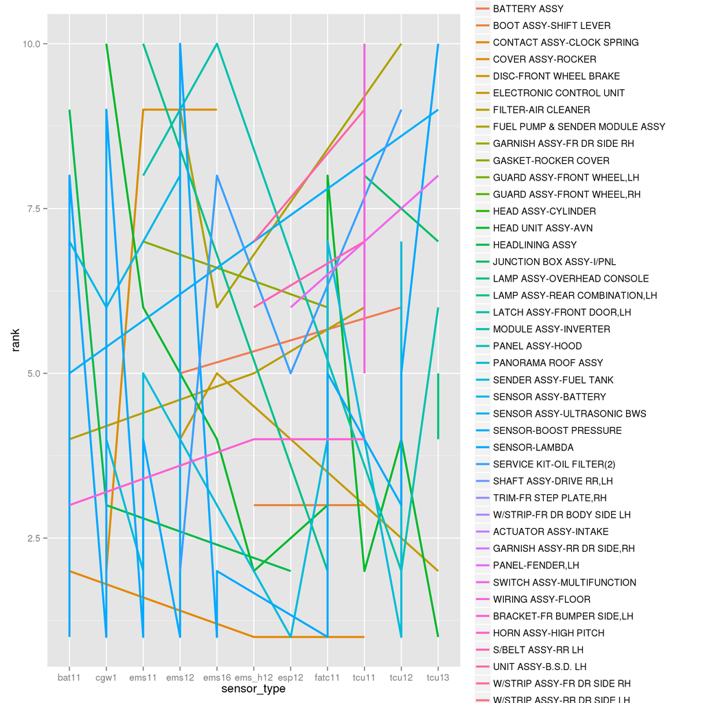

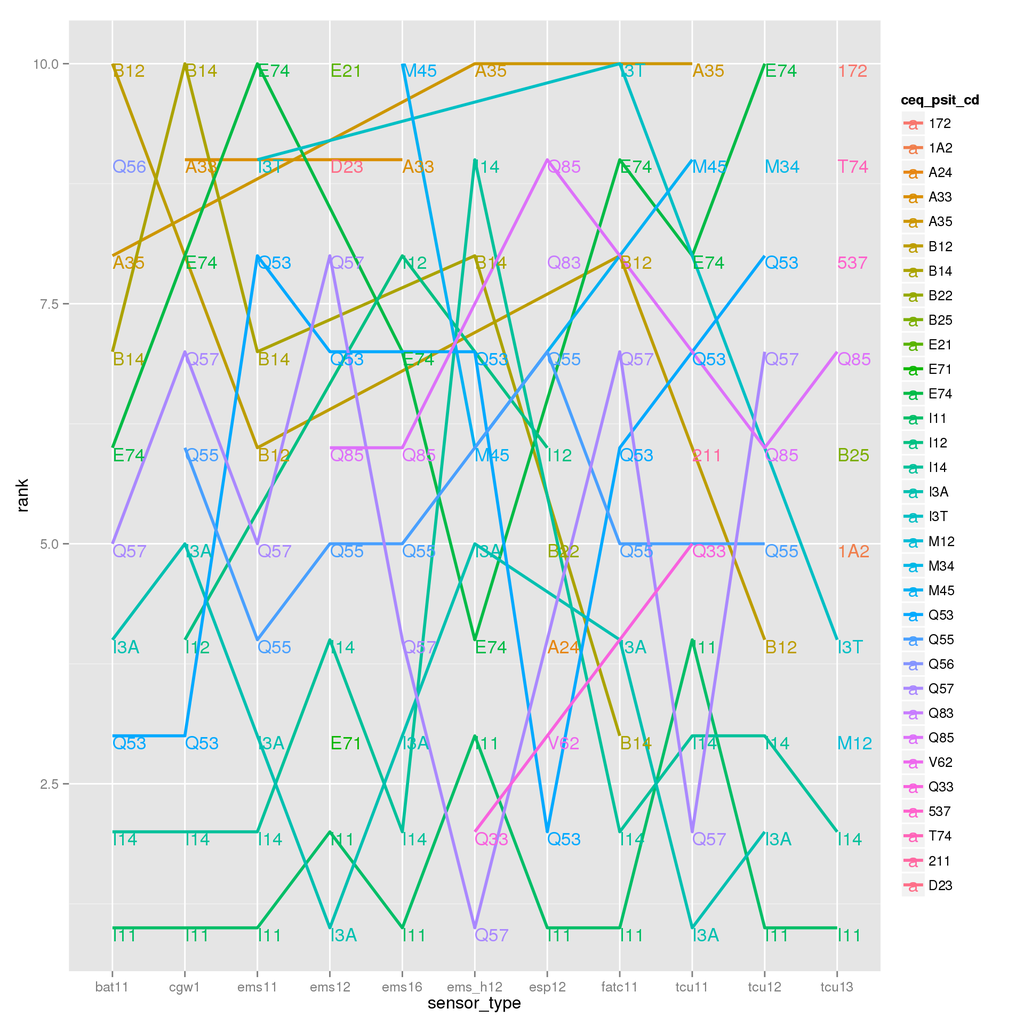